# Interactive effect of temp and land use on nestling growth, nestling cort, and adult visitation rate

2025-02-11

## What do the growth and cort models look like when we use the DAG to design the model?

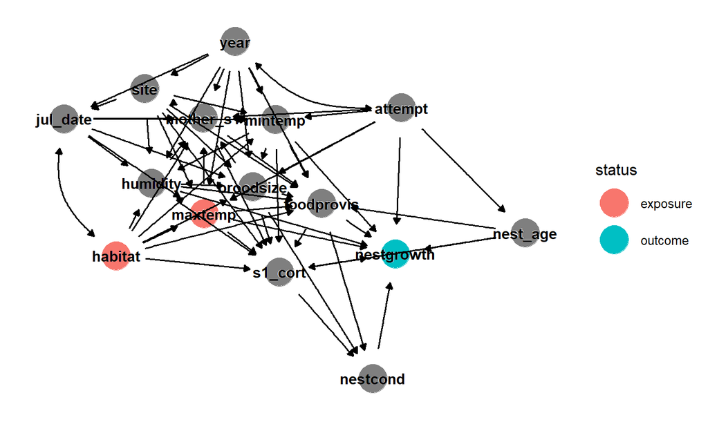

- For outcome = growth, and exposure = all four focal variables

A canonical adjustment set does not exist when exposure is all four focal variables. Does this mean I’ll need to break up the SEM?

- For outcome = growth, and exposure = habitat and max temp

```
## { attempt, jul_date, nest_age, site, year }
```

- For outcome = cort, and exposure = habitat and max temp

```
## { attempt, jul_date, nest_age, site, year }
```

- For outcome = provis, and exposure = habitat and max temp

```
## { attempt, jul_date, nest_age, site, year }
```

It looks like all three of these outcomes need the same covariates in the model. This makes sense to me, if foodprovis and cort are bound together the way we think they are. Would appreciate any thoughts/feedback on this DAG or idea.

## Do we need squared temp in the model?

- I am thinking no: go over my notes
- Land uses plotted individually with and without squared terms
- Like with NestWatch paper, compare individual land use models with and without squared terms.

I wasn’t sure where to start with this part: with new model determined by DAG or with old model so we have some reference to the previous fit. So I started with the old model and then replicated for the new model to compare.

## growth ~ temp * habitat: WEBL

Original model with min temp (support in danny_meeting_20240213):

lmerTest::lmer(gweight_scaled ~ meanmaxtempI_scaled * habitat + poly(meanmintempI_scaled,2) * habitat + age + juliandate_scaled + (1|year) + (1|site/attempt_id))

Updated model based on DAG above:

lmerTest::lmer(gweight_scaled ~ poly(meanmaxtempI_scaled,2) * habitat + age + juliandate_scaled + (1|year) + (1|site/attempt_id))

## Raw growth by temp and habitat, for referencing while looking at the modeling results

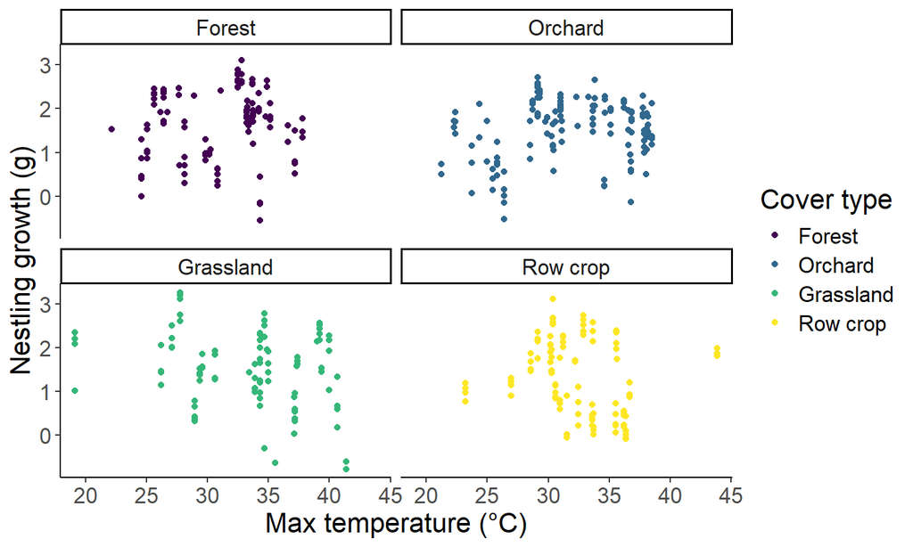

## Growth across temp and habitat: WEBL, forest

For original model with min temp:

| model | npar | AIC | BIC | logLik | deviance | Chisq | Df | Pr(>Chisq) |
| --- | --- | --- | --- | --- | --- | --- | --- | --- |
| no sq | 9 | 218.0672 | 242.1226 | -100.0336 | 200.0672 | NA | NA | NA |
| no min sq | 10 | 218.1716 | 244.8999 | -99.0858 | 198.1716 | 1.8955604 | 1 | 0.1685761 |
| sq max and min | 11 | 219.6966 | 249.0977 | -98.8483 | 197.6966 | 0.4749981 | 1 | 0.4906968 |

| model | npar | AIC | BIC | logLik | deviance | Chisq | Df | Pr(>Chisq) |
| --- | --- | --- | --- | --- | --- | --- | --- | --- |
| no sq | 9 | 218.0672 | 242.1226 | -100.03358 | 200.0672 | NA | NA | NA |
| no max sq | 10 | 218.1950 | 244.9233 | -99.09748 | 198.1950 | 1.8722025 | 1 | 0.1712230 |
| sq max and min | 11 | 219.6966 | 249.0977 | -98.84830 | 197.6966 | 0.4983559 | 1 | 0.4802234 |

```
## Linear mixed model fit by REML. t-tests use Satterthwaite's method [
## lmerModLmerTest]
## Formula: gweight_scaled ~ meanmaxtempI_scaled + meanmintempI_scaled +
##     age_scaled + juliandate_scaled + (1 | year) + (1 | site/attempt_id)
##    Data:
## dplyr::filter(g, habitat == "Forest", Species == "WEBL", !is.na(meanmaxtempI)) %>%
##     mutate(across(c(gweight, meanmaxtempI, meanmintempI, juliandate,
##         brood_size, age), ~scale(.x)[, 1], .names = "{.col}_scaled"),
##         meanmaxtempI_scaled_sq = meanmaxtempI_scaled * meanmaxtempI_scaled)
##
## REML criterion at convergence: 208.7
##
## Scaled residuals:
##      Min       1Q   Median       3Q      Max
## -2.87378 -0.45376 -0.05745  0.49090  2.39686
##
## Random effects:
##  Groups          Name        Variance Std.Dev.
##  attempt_id:site (Intercept) 0.5643   0.7512
##  site            (Intercept) 0.3150   0.5613
##  year            (Intercept) 0.2406   0.4905
##  Residual                    0.2182   0.4671
## Number of obs: 107, groups:  attempt_id:site, 23; site, 3; year, 3
##
## Fixed effects:
##                      Estimate Std. Error        df t value Pr(>|t|)
## (Intercept)           0.09402    0.46555   2.86370   0.202    0.853
## meanmaxtempI_scaled   1.05574    0.18124 101.19434   5.825 6.80e-08 ***
## meanmintempI_scaled  -1.09077    0.18817  63.34686  -5.797 2.31e-07 ***
## age_scaled           -0.60855    0.07488  99.38138  -8.127 1.26e-12 ***
## juliandate_scaled    -0.13739    0.19774  18.05888  -0.695    0.496
## ---
## Signif. codes:  0 '***' 0.001 '**' 0.01 '*' 0.05 '.' 0.1 ' ' 1
##
## Correlation of Fixed Effects:
##             (Intr) mnmxI_ mnmnI_ ag_scl
## mnmxtmpI_sc -0.010
## mnmntmpI_sc  0.053 -0.508
## age_scaled   0.024 -0.056  0.092
## julndt_scld -0.069 -0.249 -0.262 -0.286
```

Essentially, it looks like min and max function interchangeably, more or less. Neither adds much to the fit for forest.

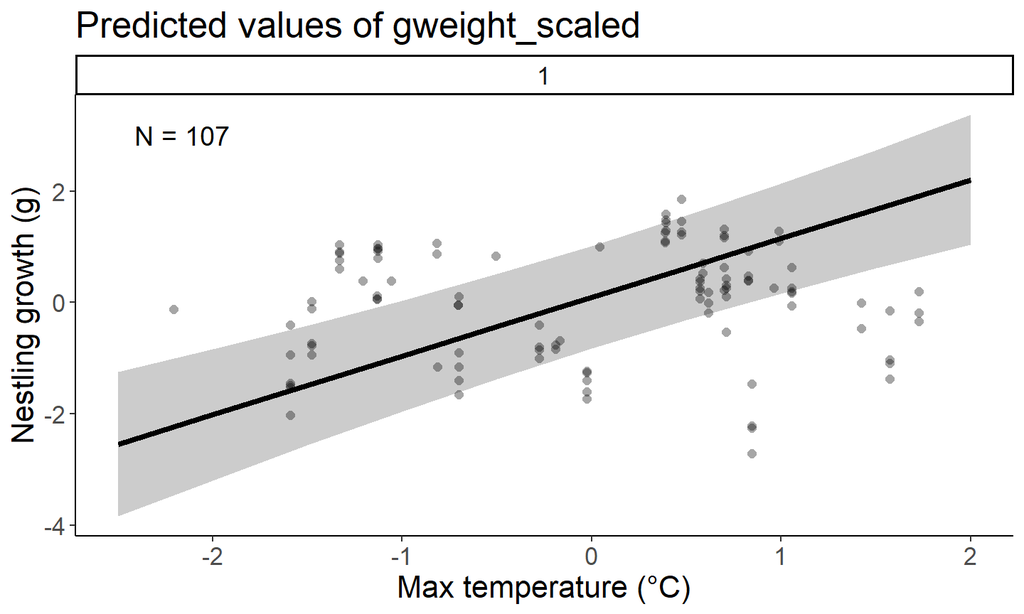

## Growth across temp and habitat: WEBL, forest

For updated model based on DAG, squared temp is not supported:

| model | npar | AIC | BIC | logLik | deviance | Chisq | Df | Pr(>Chisq) |
| --- | --- | --- | --- | --- | --- | --- | --- | --- |
| no sq | 8 | 236.5950 | 257.9777 | -110.2975 | 220.5950 | NA | NA | NA |
| sq max temp | 9 | 237.0422 | 261.0976 | -109.5211 | 219.0422 | 1.552842 | 1 | 0.2127164 |

```
## Linear mixed model fit by REML. t-tests use Satterthwaite's method [
## lmerModLmerTest]
## Formula:
## gweight_scaled ~ meanmaxtempI_scaled + age_scaled + juliandate_scaled +
##     (1 | year) + (1 | site/attempt_id)
##    Data:
## dplyr::filter(g, habitat == "Forest", Species == "WEBL", !is.na(meanmaxtempI)) %>%
##     mutate(across(c(gweight, meanmaxtempI, meanmintempI, juliandate,
##         brood_size, age), ~scale(.x)[, 1], .names = "{.col}_scaled"),
##         meanmaxtempI_scaled_sq = meanmaxtempI_scaled * meanmaxtempI_scaled)
##
## REML criterion at convergence: 230.3
##
## Scaled residuals:
##     Min      1Q  Median      3Q     Max
## -3.2349 -0.4996  0.0098  0.5604  2.0588
##
## Random effects:
##  Groups          Name        Variance  Std.Dev.
##  attempt_id:site (Intercept) 3.518e-01 0.5931518
##  site            (Intercept) 1.357e-07 0.0003684
##  year            (Intercept) 1.040e-02 0.1020033
##  Residual                    3.304e-01 0.5747735
## Number of obs: 107, groups:  attempt_id:site, 23; site, 3; year, 3
##
## Fixed effects:
##                      Estimate Std. Error        df t value Pr(>|t|)
## (Intercept)           0.13661    0.15082   1.61623   0.906   0.4795
## meanmaxtempI_scaled   0.34082    0.14147  23.69619   2.409   0.0241 *
## age_scaled           -0.57244    0.08398 101.92091  -6.816 6.73e-10 ***
## juliandate_scaled    -0.18412    0.15235  20.79483  -1.209   0.2404
## ---
## Signif. codes:  0 '***' 0.001 '**' 0.01 '*' 0.05 '.' 0.1 ' ' 1
##
## Correlation of Fixed Effects:
##             (Intr) mnmxI_ ag_scl
## mnmxtmpI_sc -0.009
## age_scaled   0.006  0.038
## julndt_scld -0.039 -0.454 -0.265
```

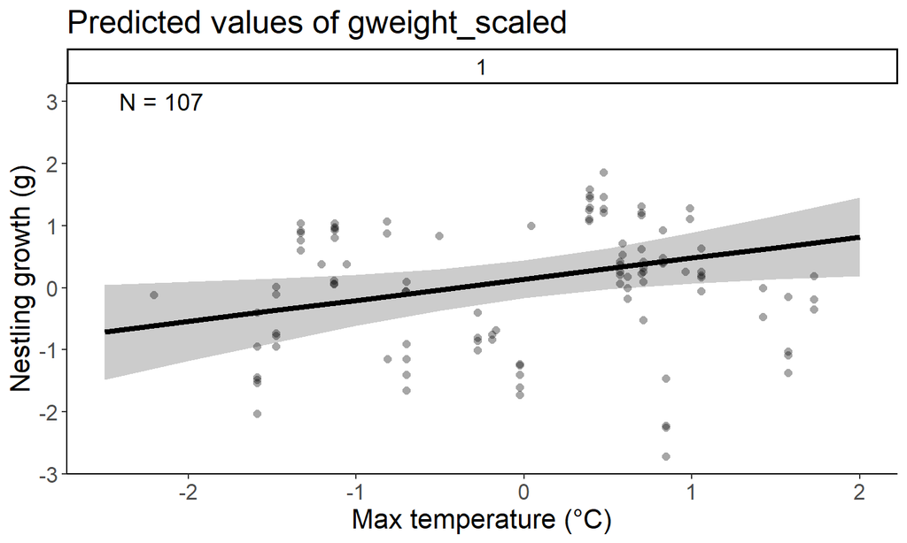

## Predicted growth across temp and habitat: WEBL, orchard

For original model with min temp:

| model | npar | AIC | BIC | logLik | deviance | Chisq | Df | Pr(>Chisq) |
| --- | --- | --- | --- | --- | --- | --- | --- | --- |
| no sq | 9 | 295.2585 | 321.6688 | -138.6292 | 277.2585 | NA | NA | NA |
| no min sq | 10 | 295.8124 | 325.1571 | -137.9062 | 275.8124 | 1.4460841 | 1 | 0.2291573 |
| sq max and min | 11 | 297.6701 | 329.9493 | -137.8350 | 275.6701 | 0.1423288 | 1 | 0.7059768 |

| model | npar | AIC | BIC | logLik | deviance | Chisq | Df | Pr(>Chisq) |
| --- | --- | --- | --- | --- | --- | --- | --- | --- |
| no sq | 9 | 295.2585 | 321.6688 | -138.6292 | 277.2585 | NA | NA | NA |
| no max sq | 10 | 297.1173 | 326.4620 | -138.5586 | 277.1173 | 0.141236 | 1 | 0.7070554 |
| sq max and min | 11 | 297.6701 | 329.9493 | -137.8350 | 275.6701 | 1.447177 | 1 | 0.2289815 |

```
## Linear mixed model fit by REML. t-tests use Satterthwaite's method [
## lmerModLmerTest]
## Formula: gweight_scaled ~ meanmaxtempI_scaled + meanmintempI_scaled +
##     age_scaled + juliandate_scaled + (1 | year) + (1 | site/attempt_id)
##    Data:
## dplyr::filter(g, habitat == "Orchard", Species == "WEBL", !is.na(meanmaxtempI)) %>%
##     mutate(across(c(gweight, meanmaxtempI, meanmintempI, juliandate,
##         brood_size, age), ~scale(.x)[, 1], .names = "{.col}_scaled"),
##         meanmaxtempI_scaled_sq = meanmaxtempI_scaled * meanmaxtempI_scaled)
##
## REML criterion at convergence: 289.3
##
## Scaled residuals:
##      Min       1Q   Median       3Q      Max
## -2.64578 -0.68968  0.06854  0.52911  2.82622
##
## Random effects:
##  Groups          Name        Variance  Std.Dev.
##  attempt_id:site (Intercept) 3.420e-01 5.848e-01
##  year            (Intercept) 0.000e+00 0.000e+00
##  site            (Intercept) 8.353e-09 9.139e-05
##  Residual                    3.155e-01 5.617e-01
## Number of obs: 139, groups:  attempt_id:site, 28; year, 3; site, 2
##
## Fixed effects:
##                       Estimate Std. Error         df t value Pr(>|t|)
## (Intercept)          -0.001558   0.124163  16.805215  -0.013 0.990136
## meanmaxtempI_scaled   0.678484   0.173674  93.962539   3.907 0.000176 ***
## meanmintempI_scaled   0.418298   0.224657  36.904989   1.862 0.070589 .
## age_scaled           -0.642347   0.058948 127.871608 -10.897  < 2e-16 ***
## juliandate_scaled    -0.942191   0.200721  30.143666  -4.694 5.46e-05 ***
## ---
## Signif. codes:  0 '***' 0.001 '**' 0.01 '*' 0.05 '.' 0.1 ' ' 1
##
## Correlation of Fixed Effects:
##             (Intr) mnmxI_ mnmnI_ ag_scl
## mnmxtmpI_sc  0.048
## mnmntmpI_sc -0.024 -0.544
## age_scaled   0.000 -0.093  0.073
## julndt_scld -0.009 -0.232 -0.491 -0.110
## optimizer (nloptwrap) convergence code: 0 (OK)
## boundary (singular) fit: see help('isSingular')
```

Similar story for orchard as for forest.

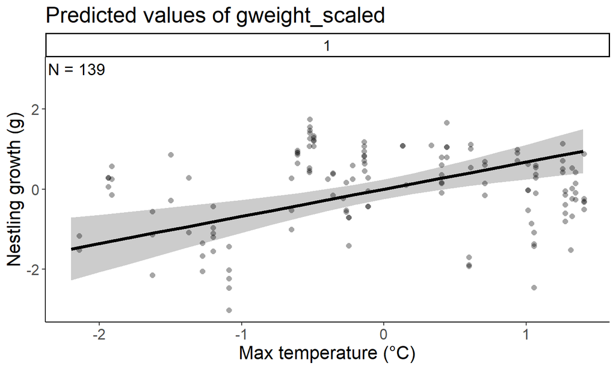

## Predicted growth across temp and habitat: WEBL, orchard

For updated model based on DAG, squared max temp does not add much:

| model | npar | AIC | BIC | logLik | deviance | Chisq | Df | Pr(>Chisq) |
| --- | --- | --- | --- | --- | --- | --- | --- | --- |
| no sq | 8 | 296.7566 | 320.2324 | -140.3783 | 280.7566 | NA | NA | NA |
| sq max temp | 9 | 297.5071 | 323.9174 | -139.7535 | 279.5071 | 1.249484 | 1 | 0.263651 |

```
## Linear mixed model fit by REML. t-tests use Satterthwaite's method [
## lmerModLmerTest]
## Formula:
## gweight_scaled ~ meanmaxtempI_scaled + age_scaled + juliandate_scaled +
##     (1 | year) + (1 | site/attempt_id)
##    Data:
## dplyr::filter(g, habitat == "Orchard", Species == "WEBL", !is.na(meanmaxtempI)) %>%
##     mutate(across(c(gweight, meanmaxtempI, meanmintempI, juliandate,
##         brood_size, age), ~scale(.x)[, 1], .names = "{.col}_scaled"),
##         meanmaxtempI_scaled_sq = meanmaxtempI_scaled * meanmaxtempI_scaled)
##
## REML criterion at convergence: 291.5
##
## Scaled residuals:
##      Min       1Q   Median       3Q      Max
## -2.65423 -0.64341  0.09894  0.56677  2.74288
##
## Random effects:
##  Groups          Name        Variance  Std.Dev.
##  attempt_id:site (Intercept) 3.165e-01 0.5625940
##  year            (Intercept) 7.129e-03 0.0844320
##  site            (Intercept) 2.061e-08 0.0001436
##  Residual                    3.259e-01 0.5708333
## Number of obs: 139, groups:  attempt_id:site, 28; year, 3; site, 2
##
## Fixed effects:
##                      Estimate Std. Error        df t value Pr(>|t|)
## (Intercept)           0.01249    0.13166   0.38628   0.095 0.952919
## meanmaxtempI_scaled   0.84015    0.14616  83.24033   5.748 1.44e-07 ***
## age_scaled           -0.64802    0.05950 129.66929 -10.891  < 2e-16 ***
## juliandate_scaled    -0.75173    0.17335  29.56136  -4.336 0.000154 ***
## ---
## Signif. codes:  0 '***' 0.001 '**' 0.01 '*' 0.05 '.' 0.1 ' ' 1
##
## Correlation of Fixed Effects:
##             (Intr) mnmxI_ ag_scl
## mnmxtmpI_sc  0.036
## age_scaled   0.010 -0.065
## julndt_scld -0.039 -0.687 -0.081
## optimizer (nloptwrap) convergence code: 0 (OK)
## unable to evaluate scaled gradient
## Model failed to converge: degenerate  Hessian with 1 negative eigenvalues
```

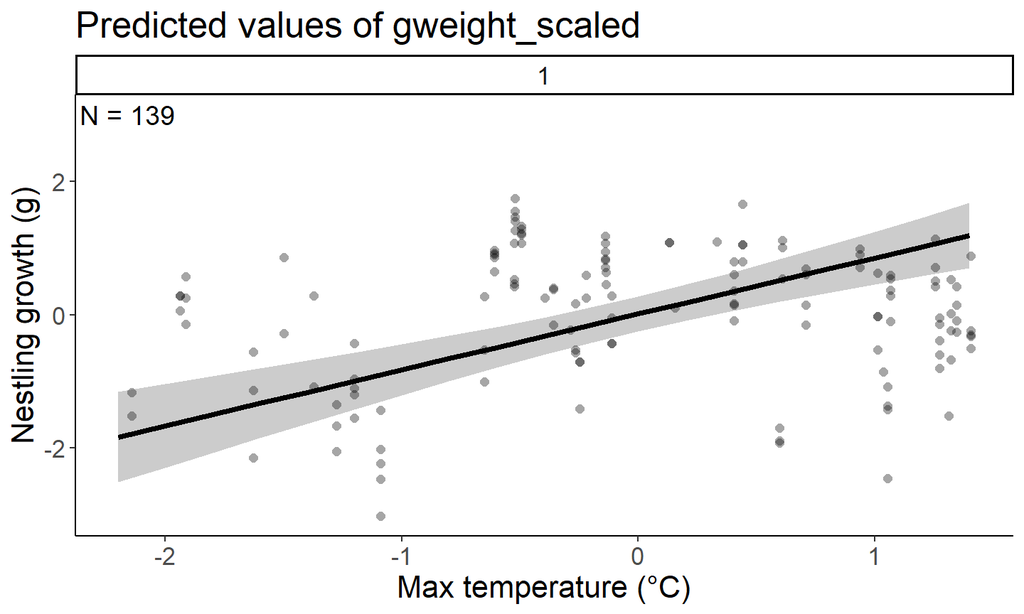

## Predicted growth across temp and habitat: WEBL, grassland

For original model with min temp, squared min temp helps:

| model | npar | AIC | BIC | logLik | deviance | Chisq | Df | Pr(>Chisq) |
| --- | --- | --- | --- | --- | --- | --- | --- | --- |
| no sq | 9 | 227.2808 | 250.2657 | -104.64042 | 209.2808 | NA | NA | NA |
| no min sq | 10 | 221.6034 | 247.1422 | -100.80169 | 201.6034 | 7.677455 | 1 | 5.591498e-03 |
| sq max and min | 11 | 206.6570 | 234.7496 | -92.32848 | 184.6570 | 16.946430 | 1 | 3.844956e-05 |

| model | npar | AIC | BIC | logLik | deviance | Chisq | Df | Pr(>Chisq) |
| --- | --- | --- | --- | --- | --- | --- | --- | --- |
| no sq | 9 | 227.2808 | 250.2657 | -104.64042 | 209.2808 | NA | NA | NA |
| no max sq | 10 | 206.1892 | 231.7280 | -93.09460 | 186.1892 | 23.091646 | 1 | 1.544603e-06 |
| sq max and min | 11 | 206.6570 | 234.7496 | -92.32848 | 184.6570 | 1.532238 | 1 | 2.157769e-01 |

```
## Linear mixed model fit by REML. t-tests use Satterthwaite's method [
## lmerModLmerTest]
## Formula: gweight_scaled ~ meanmaxtempI_scaled + poly(meanmintempI_scaled,
##     2) + age_scaled + juliandate_scaled + (1 | year) + (1 | site/attempt_id)
##    Data:
## dplyr::filter(g, habitat == "Grassland", Species == "WEBL", !is.na(meanmaxtempI)) %>%
##     mutate(across(c(gweight, meanmaxtempI, meanmintempI, juliandate,
##         brood_size, age), ~scale(.x)[, 1], .names = "{.col}_scaled"),
##         meanmaxtempI_scaled_sq = meanmaxtempI_scaled * meanmaxtempI_scaled)
##
## REML criterion at convergence: 187.5
##
## Scaled residuals:
##      Min       1Q   Median       3Q      Max
## -2.67203 -0.59526 -0.01841  0.60774  2.43247
##
## Random effects:
##  Groups          Name        Variance Std.Dev.
##  attempt_id:site (Intercept) 1.4039   1.1849
##  site            (Intercept) 0.4322   0.6574
##  year            (Intercept) 0.0000   0.0000
##  Residual                    0.2384   0.4882
## Number of obs: 95, groups:  attempt_id:site, 17; site, 3; year, 3
##
## Fixed effects:
##                               Estimate Std. Error       df t value Pr(>|t|)
## (Intercept)                    0.19626    0.49398  2.05610   0.397  0.72860
## meanmaxtempI_scaled           -1.07971    0.21965 85.30072  -4.916 4.24e-06 ***
## poly(meanmintempI_scaled, 2)1 20.40296    3.04360 74.27753   6.704 3.44e-09 ***
## poly(meanmintempI_scaled, 2)2 -8.46346    1.27579 84.83573  -6.634 2.90e-09 ***
## age_scaled                    -0.98732    0.08943 80.18208 -11.040  < 2e-16 ***
## juliandate_scaled             -1.00593    0.28610 10.64268  -3.516  0.00508 **
## ---
## Signif. codes:  0 '***' 0.001 '**' 0.01 '*' 0.05 '.' 0.1 ' ' 1
##
## Correlation of Fixed Effects:
##             (Intr) mnmxI_ p(I_,2)1 p(I_,2)2 ag_scl
## mnmxtmpI_sc -0.040
## ply(mI_,2)1  0.045 -0.811
## ply(mI_,2)2 -0.045  0.670 -0.759
## age_scaled   0.057  0.430 -0.580    0.530
## julndt_scld -0.203  0.091 -0.240    0.175   -0.243
## optimizer (nloptwrap) convergence code: 0 (OK)
## boundary (singular) fit: see help('isSingular')
```

Adding squared min when you already have squared max does add some fit, but adding squared max when you have squared min does not add fit. So the squared min term is more important in grassland than the squared max term.

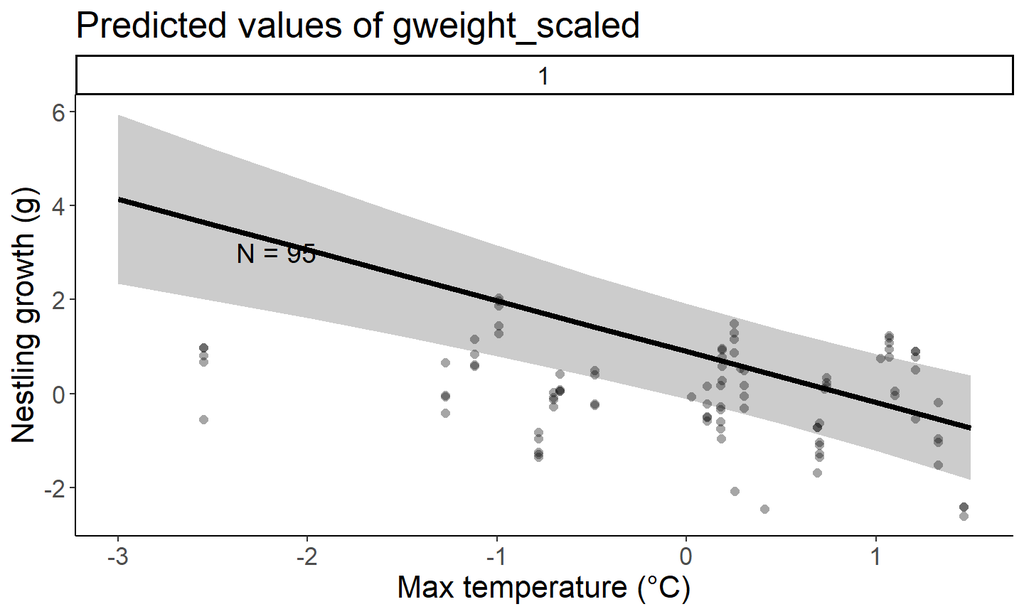

## Predicted growth across temp and habitat: WEBL, grassland

For updated model based on DAG, squared term helps fit:

| model | npar | AIC | BIC | logLik | deviance | Chisq | Df | Pr(>Chisq) |
| --- | --- | --- | --- | --- | --- | --- | --- | --- |
| no sq | 8 | 232.4418 | 252.8728 | -108.2209 | 216.4418 | NA | NA | NA |
| sq max temp | 9 | 230.1277 | 253.1126 | -106.0638 | 212.1277 | 4.31411 | 1 | 0.03779754 |

```
## Linear mixed model fit by REML. t-tests use Satterthwaite's method [
## lmerModLmerTest]
## Formula: gweight_scaled ~ poly(meanmaxtempI_scaled, 2) + age_scaled +
##     juliandate_scaled + (1 | year) + (1 | site/attempt_id)
##    Data:
## dplyr::filter(g, habitat == "Grassland", Species == "WEBL", !is.na(meanmaxtempI)) %>%
##     mutate(across(c(gweight, meanmaxtempI, meanmintempI, juliandate,
##         brood_size, age), ~scale(.x)[, 1], .names = "{.col}_scaled"),
##         meanmaxtempI_scaled_sq = meanmaxtempI_scaled * meanmaxtempI_scaled)
##
## REML criterion at convergence: 214.3
##
## Scaled residuals:
##      Min       1Q   Median       3Q      Max
## -2.70242 -0.52081  0.08201  0.59569  2.22645
##
## Random effects:
##  Groups          Name        Variance Std.Dev.
##  attempt_id:site (Intercept) 0.3316   0.5758
##  site            (Intercept) 0.1552   0.3940
##  year            (Intercept) 0.0000   0.0000
##  Residual                    0.4235   0.6508
## Number of obs: 95, groups:  attempt_id:site, 17; site, 3; year, 3
##
## Fixed effects:
##                               Estimate Std. Error       df t value Pr(>|t|)
## (Intercept)                   -0.06529    0.28285  1.96823  -0.231    0.839
## poly(meanmaxtempI_scaled, 2)1  0.55402    1.40390 60.92457   0.395    0.694
## poly(meanmaxtempI_scaled, 2)2 -1.85597    0.89979 89.79830  -2.063    0.042 *
## age_scaled                    -0.66098    0.08786 87.54865  -7.523 4.42e-11 ***
## juliandate_scaled             -0.29145    0.17219 14.17026  -1.693    0.112
## ---
## Signif. codes:  0 '***' 0.001 '**' 0.01 '*' 0.05 '.' 0.1 ' ' 1
##
## Correlation of Fixed Effects:
##             (Intr) p(I_,2)1 p(I_,2)2 ag_scl
## ply(mI_,2)1  0.006
## ply(mI_,2)2  0.012  0.067
## age_scaled   0.048 -0.070    0.326
## julndt_scld -0.130 -0.428   -0.046   -0.240
## optimizer (nloptwrap) convergence code: 0 (OK)
## boundary (singular) fit: see help('isSingular')
```

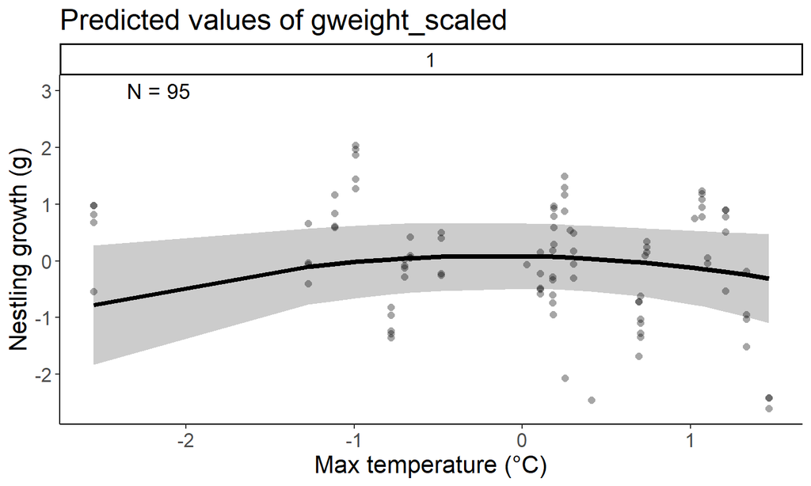

## Predicted growth across temp and habitat: WEBL, row crop

For original model with min temp:

| model | npar | AIC | BIC | logLik | deviance | Chisq | Df | Pr(>Chisq) |
| --- | --- | --- | --- | --- | --- | --- | --- | --- |
| no sq | 9 | 202.4161 | 225.5885 | -92.20804 | 184.4161 | NA | NA | NA |
| no min sq | 10 | 204.4010 | 230.1481 | -92.20049 | 184.4010 | 0.01509843 | 1 | 0.902205541 |
| sq max and min | 11 | 198.2916 | 226.6134 | -88.14578 | 176.2916 | 8.10943133 | 1 | 0.004403554 |

| model | npar | AIC | BIC | logLik | deviance | Chisq | Df | Pr(>Chisq) |
| --- | --- | --- | --- | --- | --- | --- | --- | --- |
| no sq | 9 | 202.4161 | 225.5885 | -92.20804 | 184.4161 | NA | NA | NA |
| no max sq | 10 | 197.8931 | 223.6403 | -88.94657 | 177.8931 | 6.522938 | 1 | 0.01064919 |
| sq max and min | 11 | 198.2916 | 226.6134 | -88.14578 | 176.2916 | 1.601591 | 1 | 0.20567783 |

```
## Linear mixed model fit by REML. t-tests use Satterthwaite's method [
## lmerModLmerTest]
## Formula: gweight_scaled ~ meanmaxtempI_scaled + poly(meanmintempI_scaled,
##     2) + age_scaled + juliandate_scaled + (1 | year) + (1 | site/attempt_id)
##    Data:
## dplyr::filter(g, habitat == "Row crop", Species == "WEBL", !is.na(meanmaxtempI)) %>%
##     mutate(across(c(gweight, meanmaxtempI, meanmintempI, juliandate,
##         brood_size, age), ~scale(.x)[, 1], .names = "{.col}_scaled"),
##         meanmaxtempI_scaled_sq = meanmaxtempI_scaled * meanmaxtempI_scaled)
##
## REML criterion at convergence: 178.9
##
## Scaled residuals:
##      Min       1Q   Median       3Q      Max
## -2.36381 -0.72993 -0.00609  0.55502  2.38452
##
## Random effects:
##  Groups          Name        Variance  Std.Dev.
##  attempt_id:site (Intercept) 1.922e+00 1.387e+00
##  site            (Intercept) 0.000e+00 0.000e+00
##  year            (Intercept) 3.006e-09 5.483e-05
##  Residual                    1.998e-01 4.469e-01
## Number of obs: 97, groups:  attempt_id:site, 17; site, 3; year, 3
##
## Fixed effects:
##                               Estimate Std. Error      df t value Pr(>|t|)
## (Intercept)                     0.1804     0.3444  3.3854   0.524 0.632707
## meanmaxtempI_scaled            -0.4695     0.1881 22.3156  -2.496 0.020435 *
## poly(meanmintempI_scaled, 2)1   4.9051     3.2667 12.4005   1.502 0.158241
## poly(meanmintempI_scaled, 2)2  -7.3251     1.7748 20.5498  -4.127 0.000498 ***
## age_scaled                     -1.0427     0.1020 36.3669 -10.222 3.06e-12 ***
## juliandate_scaled               0.2824     0.3491  4.2346   0.809 0.461527
## ---
## Signif. codes:  0 '***' 0.001 '**' 0.01 '*' 0.05 '.' 0.1 ' ' 1
##
## Correlation of Fixed Effects:
##             (Intr) mnmxI_ p(I_,2)1 p(I_,2)2 ag_scl
## mnmxtmpI_sc -0.004
## ply(mI_,2)1  0.083 -0.728
## ply(mI_,2)2 -0.109 -0.343 -0.118
## age_scaled  -0.029  0.125 -0.404    0.142
## julndt_scld -0.116  0.107 -0.370    0.255   -0.239
## optimizer (nloptwrap) convergence code: 0 (OK)
## boundary (singular) fit: see help('isSingular')
```

Squared min helps fit, but squared max does not appear to help fit

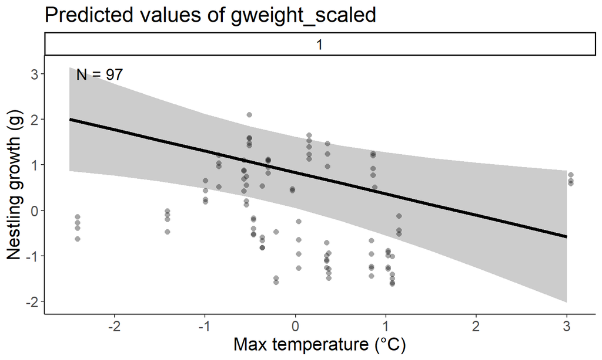

## Predicted growth across temp and habitat: WEBL, row crop

For updated model based on DAG, squared term is not supported:

| model | npar | AIC | BIC | logLik | deviance | Chisq | Df | Pr(>Chisq) |
| --- | --- | --- | --- | --- | --- | --- | --- | --- |
| no sq | 8 | 200.4665 | 221.0642 | -92.23325 | 184.4665 | NA | NA | NA |
| sq max temp | 9 | 202.4582 | 225.6306 | -92.22910 | 184.4582 | 0.008307228 | 1 | 0.9273782 |

```
## Linear mixed model fit by REML. t-tests use Satterthwaite's method [
## lmerModLmerTest]
## Formula:
## gweight_scaled ~ meanmaxtempI_scaled + age_scaled + juliandate_scaled +
##     (1 | year) + (1 | site/attempt_id)
##    Data:
## dplyr::filter(g, habitat == "Row crop", Species == "WEBL", !is.na(meanmaxtempI)) %>%
##     mutate(across(c(gweight, meanmaxtempI, meanmintempI, juliandate,
##         brood_size, age), ~scale(.x)[, 1], .names = "{.col}_scaled"),
##         meanmaxtempI_scaled_sq = meanmaxtempI_scaled * meanmaxtempI_scaled)
##
## REML criterion at convergence: 193.6
##
## Scaled residuals:
##      Min       1Q   Median       3Q      Max
## -2.69415 -0.52564  0.01512  0.58591  2.52783
##
## Random effects:
##  Groups          Name        Variance Std.Dev.
##  attempt_id:site (Intercept) 0.5408   0.7354
##  site            (Intercept) 0.0000   0.0000
##  year            (Intercept) 0.0000   0.0000
##  Residual                    0.2682   0.5179
## Number of obs: 97, groups:  attempt_id:site, 17; site, 3; year, 3
##
## Fixed effects:
##                      Estimate Std. Error        df t value Pr(>|t|)
## (Intercept)          0.004218   0.188812 13.389335   0.022  0.98251
## meanmaxtempI_scaled -0.531807   0.105509 89.158300  -5.040 2.42e-06 ***
## age_scaled          -0.894748   0.090288 88.689236  -9.910 5.09e-16 ***
## juliandate_scaled    0.702129   0.182455 15.973371   3.848  0.00142 **
## ---
## Signif. codes:  0 '***' 0.001 '**' 0.01 '*' 0.05 '.' 0.1 ' ' 1
##
## Correlation of Fixed Effects:
##             (Intr) mnmxI_ ag_scl
## mnmxtmpI_sc  0.042
## age_scaled  -0.024 -0.257
## julndt_scld -0.058 -0.237 -0.278
## optimizer (nloptwrap) convergence code: 0 (OK)
## boundary (singular) fit: see help('isSingular')
```

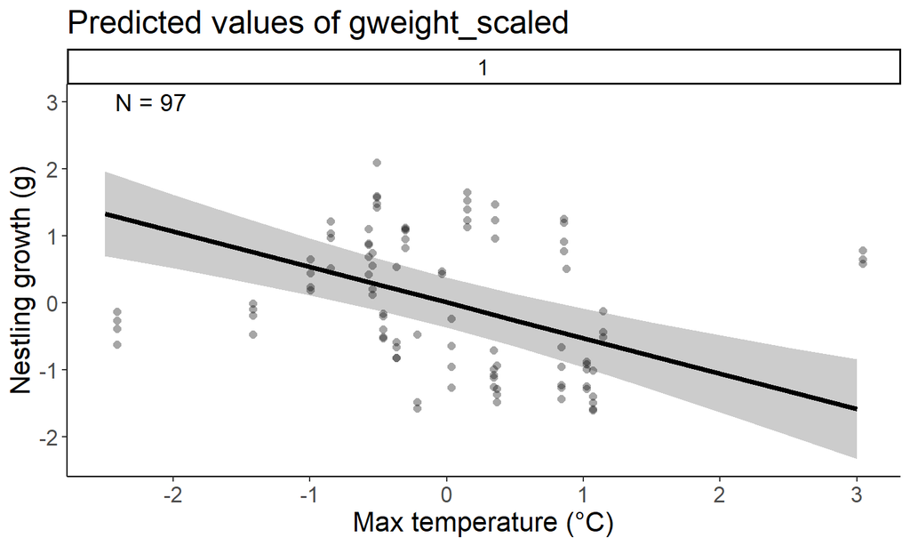

## Conclusions

Squared min temp (but not squared max temp) is important in grassland and row crop with the original model, and squared max temp is important in grassland with the updated model. Can we decide to not use squared max temp for WEBL?

| Habitat | Sq max (orig) | Sq min (orig) | Sq max (update) |
| --- | --- | --- | --- |
| Forest |  |  |  |
| Orchard |  |  |  |
| Grassland |  | * | * |
| Row crop |  | * |  |

## Revisiting growth ~ temp * habitat: TRES

Original model (support in danny_meeting_20240213):

lmerTest::lmer(gweight_scaled ~ meanmaxtempI_scaled * habitat + poly(meanmintempI_scaled,2) * habitat + age + juliandate_scaled + (1|year) + (1|site/attempt_id))

Updated model:

lmerTest::lmer(gweight_scaled ~ meanmaxtempI_scaled * habitat + age + juliandate_scaled + (1|year) + (1|site/attempt_id))

## Raw growth by temp and habitat, for referencing while looking at the modeling results

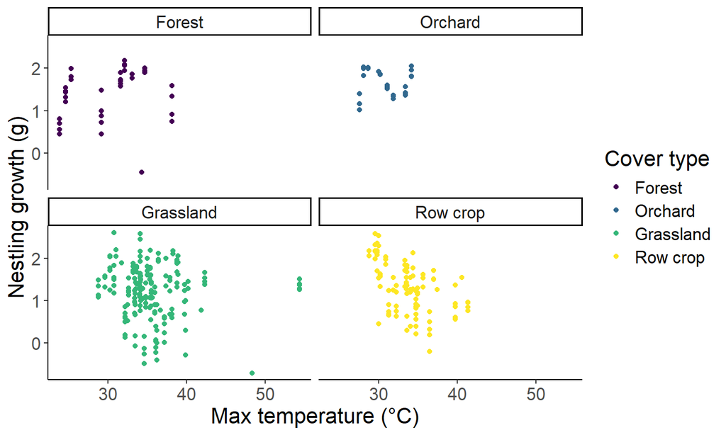

## Growth across temp and habitat: TRES, forest

For original model with min temp:

| model | npar | AIC | BIC | logLik | deviance | Chisq | Df | Pr(>Chisq) |
| --- | --- | --- | --- | --- | --- | --- | --- | --- |
| no sq | 9 | 88.39250 | 103.36455 | -35.19625 | 70.39250 | NA | NA | NA |
| no min sq | 10 | 79.60070 | 96.23631 | -29.80035 | 59.60070 | 10.791799 | 1 | 0.001019508 |
| sq max and min | 11 | 81.32366 | 99.62284 | -29.66183 | 59.32366 | 0.277034 | 1 | 0.598651863 |

| model | npar | AIC | BIC | logLik | deviance | Chisq | Df | Pr(>Chisq) |
| --- | --- | --- | --- | --- | --- | --- | --- | --- |
| no sq | 9 | 88.39250 | 103.36455 | -35.19625 | 70.39250 | NA | NA | NA |
| no max sq | 10 | 82.38612 | 99.02174 | -31.19306 | 62.38612 | 8.006378 | 1 | 0.004661288 |
| sq max and min | 11 | 81.32366 | 99.62284 | -29.66183 | 59.32366 | 3.062455 | 1 | 0.080120542 |

```
## Linear mixed model fit by REML. t-tests use Satterthwaite's method [
## lmerModLmerTest]
## Formula: gweight_scaled ~ poly(meanmaxtempI_scaled, 2) + meanmintempI_scaled +
##     age_scaled + juliandate_scaled + (1 | year) + (1 | site/attempt_id)
##    Data:
## dplyr::filter(g, habitat == "Forest", Species == "TRES", !is.na(meanmaxtempI)) %>%
##     mutate(across(c(gweight, meanmaxtempI, meanmintempI, juliandate,
##         brood_size, age), ~scale(.x)[, 1], .names = "{.col}_scaled"),
##         meanmaxtempI_scaled_sq = meanmaxtempI_scaled * meanmaxtempI_scaled)
##
## REML criterion at convergence: 53.2
##
## Scaled residuals:
##      Min       1Q   Median       3Q      Max
## -2.11488 -0.46661 -0.00442  0.26120  2.70144
##
## Random effects:
##  Groups          Name        Variance  Std.Dev.
##  attempt_id:site (Intercept) 3.227e+00 1.7963123
##  site            (Intercept) 8.699e-08 0.0002949
##  year            (Intercept) 0.000e+00 0.0000000
##  Residual                    1.282e-01 0.3581150
## Number of obs: 39, groups:  attempt_id:site, 8; site, 3; year, 3
##
## Fixed effects:
##                               Estimate Std. Error      df t value Pr(>|t|)
## (Intercept)                    -0.3404     0.6839  3.6838  -0.498   0.6469
## poly(meanmaxtempI_scaled, 2)1  -8.1884     6.6375  3.7475  -1.234   0.2891
## poly(meanmaxtempI_scaled, 2)2  -8.7192     2.7670  4.7890  -3.151   0.0269 *
## meanmintempI_scaled             0.9689     0.7771  4.5250   1.247   0.2731
## age_scaled                     -1.2195     0.3265  4.3625  -3.735   0.0173 *
## juliandate_scaled               0.5845     0.7676  3.8351   0.762   0.4905
## ---
## Signif. codes:  0 '***' 0.001 '**' 0.01 '*' 0.05 '.' 0.1 ' ' 1
##
## Correlation of Fixed Effects:
##             (Intr) p(I_,2)1 p(I_,2)2 mnmnI_ ag_scl
## ply(mI_,2)1 -0.098
## ply(mI_,2)2 -0.041  0.014
## mnmntmpI_sc -0.021 -0.492    0.654
## age_scaled  -0.043  0.940    0.135   -0.340
## julndt_scld -0.164 -0.508   -0.399   -0.124 -0.662
## optimizer (nloptwrap) convergence code: 0 (OK)
## boundary (singular) fit: see help('isSingular')
```

For TRES in forest, it looks like squared max is more important than squared min. But looking at the graph, I’m suspecting this model is overfit to forest.

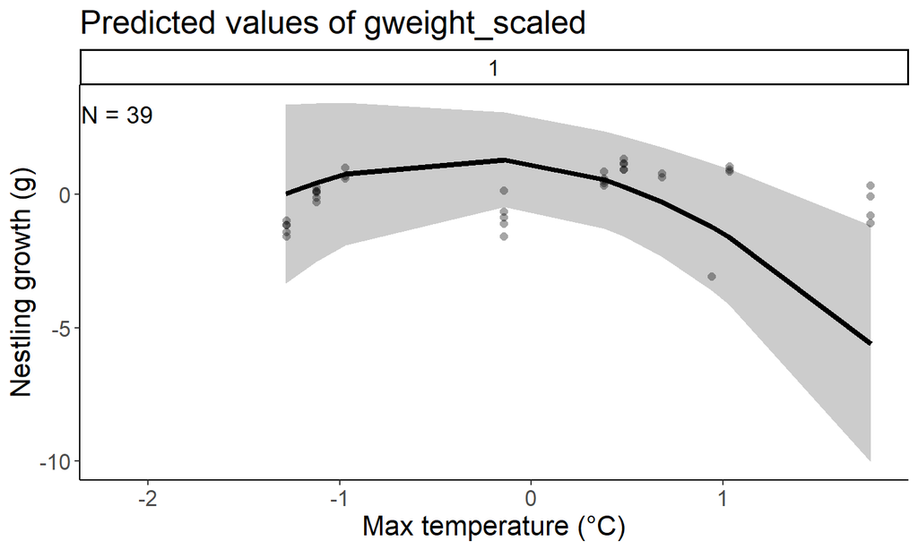

## Growth across temp and habitat: TRES, forest

For updated model based on DAG, squared temp is supported, but again, I’m suspecting some overfitting here.

| model | npar | AIC | BIC | logLik | deviance | Chisq | Df | Pr(>Chisq) |
| --- | --- | --- | --- | --- | --- | --- | --- | --- |
| no sq | 8 | 100.0217 | 113.33018 | -42.01084 | 84.02169 | NA | NA | NA |
| sq max temp | 9 | 71.3377 | 86.30975 | -26.66885 | 53.33770 | 30.68399 | 1 | 3.036603e-08 |

```
## Linear mixed model fit by REML. t-tests use Satterthwaite's method [
## lmerModLmerTest]
## Formula: gweight_scaled ~ poly(meanmaxtempI_scaled, 2) + age_scaled +
##     juliandate_scaled + (1 | year) + (1 | site/attempt_id)
##    Data:
## dplyr::filter(g, habitat == "Forest", Species == "TRES", !is.na(meanmaxtempI)) %>%
##     mutate(across(c(gweight, meanmaxtempI, meanmintempI, juliandate,
##         brood_size, age), ~scale(.x)[, 1], .names = "{.col}_scaled"),
##         meanmaxtempI_scaled_sq = meanmaxtempI_scaled * meanmaxtempI_scaled)
##
## REML criterion at convergence: 54.4
##
## Scaled residuals:
##      Min       1Q   Median       3Q      Max
## -2.07543 -0.51220  0.01188  0.28159  2.76016
##
## Random effects:
##  Groups          Name        Variance Std.Dev.
##  attempt_id:site (Intercept) 0.0000   0.0000
##  site            (Intercept) 3.0574   1.7485
##  year            (Intercept) 4.3595   2.0879
##  Residual                    0.1272   0.3567
## Number of obs: 39, groups:  attempt_id:site, 8; site, 3; year, 3
##
## Fixed effects:
##                                Estimate Std. Error        df t value Pr(>|t|)
## (Intercept)                    -0.08009    1.57483   3.58802  -0.051    0.962
## poly(meanmaxtempI_scaled, 2)1  -8.35357    1.06377  31.31532  -7.853 6.81e-09
## poly(meanmaxtempI_scaled, 2)2 -11.46025    0.81553  30.95499 -14.052 5.60e-15
## age_scaled                     -1.25937    0.10511  30.47682 -11.982 4.62e-13
## juliandate_scaled               0.73279    0.11560  30.41933   6.339 5.10e-07
##
## (Intercept)
## poly(meanmaxtempI_scaled, 2)1 ***
## poly(meanmaxtempI_scaled, 2)2 ***
## age_scaled                    ***
## juliandate_scaled             ***
## ---
## Signif. codes:  0 '***' 0.001 '**' 0.01 '*' 0.05 '.' 0.1 ' ' 1
##
## Correlation of Fixed Effects:
##             (Intr) p(I_,2)1 p(I_,2)2 ag_scl
## ply(mI_,2)1 -0.023
## ply(mI_,2)2  0.000  0.459
## age_scaled  -0.002  0.576    0.462
## julndt_scld  0.011 -0.716   -0.144   -0.538
## optimizer (nloptwrap) convergence code: 0 (OK)
## boundary (singular) fit: see help('isSingular')
```

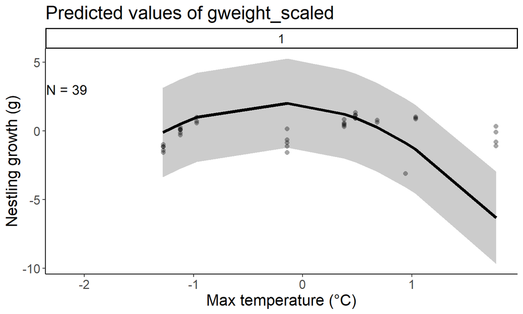

## Predicted growth across temp and habitat: TRES, orchard

For original model with min temp:

| model | npar | AIC | BIC | logLik | deviance | Chisq | Df | Pr(>Chisq) |
| --- | --- | --- | --- | --- | --- | --- | --- | --- |
| no sq | 9 | 55.60664 | 68.21741 | -18.803319 | 37.60664 | NA | NA | NA |
| no min sq | 10 | 34.07764 | 48.08962 | -7.038821 | 14.07764 | 23.528995 | 1 | 1.230454e-06 |
| sq max and min | 11 | 34.37876 | 49.79193 | -6.189381 | 12.37876 | 1.698881 | 1 | 1.924344e-01 |

| model | npar | AIC | BIC | logLik | deviance | Chisq | Df | Pr(>Chisq) |
| --- | --- | --- | --- | --- | --- | --- | --- | --- |
| no sq | 9 | 55.60664 | 68.21741 | -18.803319 | 37.60664 | NA | NA | NA |
| no max sq | 10 | 57.44833 | 71.46031 | -18.724167 | 37.44833 | 0.1583041 | 1 | 6.907227e-01 |
| sq max and min | 11 | 34.37876 | 49.79193 | -6.189381 | 12.37876 | 25.0695723 | 1 | 5.529860e-07 |

```
## Linear mixed model fit by REML. t-tests use Satterthwaite's method [
## lmerModLmerTest]
## Formula: gweight_scaled ~ poly(meanmaxtempI_scaled, 2) + meanmintempI_scaled +
##     age_scaled + juliandate_scaled + (1 | year) + (1 | site/attempt_id)
##    Data:
## dplyr::filter(g, habitat == "Orchard", Species == "TRES", !is.na(meanmaxtempI)) %>%
##     mutate(across(c(gweight, meanmaxtempI, meanmintempI, juliandate,
##         brood_size, age), ~scale(.x)[, 1], .names = "{.col}_scaled"),
##         meanmaxtempI_scaled_sq = meanmaxtempI_scaled * meanmaxtempI_scaled)
##
## REML criterion at convergence: 24.8
##
## Scaled residuals:
##     Min      1Q  Median      3Q     Max
## -1.8888 -0.4590 -0.1041  0.3129  2.2936
##
## Random effects:
##  Groups          Name        Variance Std.Dev.
##  attempt_id:site (Intercept) 0.07666  0.2769
##  year            (Intercept) 0.00000  0.0000
##  site            (Intercept) 0.00000  0.0000
##  Residual                    0.09041  0.3007
## Number of obs: 30, groups:  attempt_id:site, 8; year, 3; site, 2
##
## Fixed effects:
##                               Estimate Std. Error       df t value Pr(>|t|)
## (Intercept)                    0.01551    0.11853  2.23477   0.131  0.90672
## poly(meanmaxtempI_scaled, 2)1 -4.87439    1.10500  2.88475  -4.411  0.02344 *
## poly(meanmaxtempI_scaled, 2)2 -5.75851    0.75761  3.89614  -7.601  0.00179 **
## meanmintempI_scaled           -1.58281    0.25593  2.47892  -6.184  0.01455 *
## age_scaled                    -0.66322    0.12284  4.40761  -5.399  0.00430 **
## juliandate_scaled              1.67911    0.28997  2.47642   5.791  0.01703 *
## ---
## Signif. codes:  0 '***' 0.001 '**' 0.01 '*' 0.05 '.' 0.1 ' ' 1
##
## Correlation of Fixed Effects:
##             (Intr) p(I_,2)1 p(I_,2)2 mnmnI_ ag_scl
## ply(mI_,2)1  0.231
## ply(mI_,2)2  0.213  0.738
## mnmntmpI_sc  0.207  0.797    0.717
## age_scaled  -0.064 -0.276   -0.255   -0.214
## julndt_scld -0.230 -0.824   -0.773   -0.868  0.362
## optimizer (nloptwrap) convergence code: 0 (OK)
## boundary (singular) fit: see help('isSingular')
```

Similar story for orchard as for forest: max is more important than min, but this looks overfit to me.

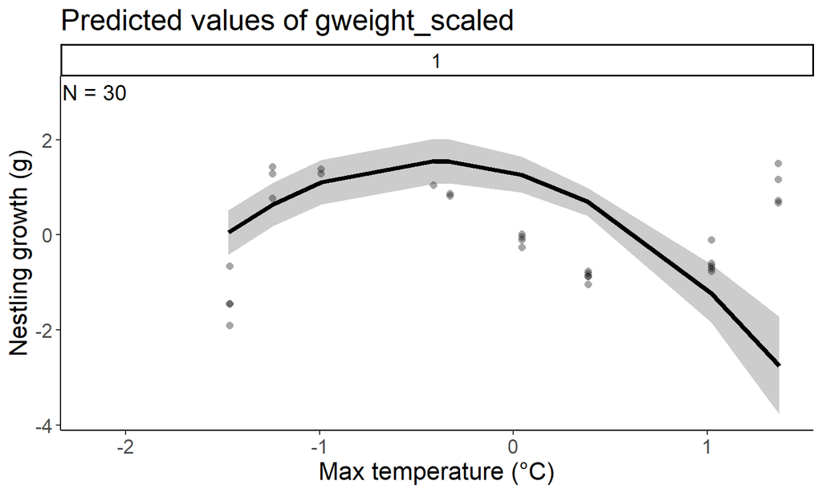

## Predicted growth across temp and habitat: TRES, orchard

For updated model based on DAG, squared max temp does not add to the fit:

| model | npar | AIC | BIC | logLik | deviance | Chisq | Df | Pr(>Chisq) |
| --- | --- | --- | --- | --- | --- | --- | --- | --- |
| no sq | 8 | 53.72544 | 64.93502 | -18.86272 | 37.72544 | NA | NA | NA |
| sq max temp | 9 | 53.25868 | 65.86946 | -17.62934 | 35.25868 | 2.466753 | 1 | 0.1162779 |

```
## Linear mixed model fit by REML. t-tests use Satterthwaite's method [
## lmerModLmerTest]
## Formula:
## gweight_scaled ~ meanmaxtempI_scaled + age_scaled + juliandate_scaled +
##     (1 | year) + (1 | site/attempt_id)
##    Data:
## dplyr::filter(g, habitat == "Orchard", Species == "TRES", !is.na(meanmaxtempI)) %>%
##     mutate(across(c(gweight, meanmaxtempI, meanmintempI, juliandate,
##         brood_size, age), ~scale(.x)[, 1], .names = "{.col}_scaled"),
##         meanmaxtempI_scaled_sq = meanmaxtempI_scaled * meanmaxtempI_scaled)
##
## REML criterion at convergence: 40.4
##
## Scaled residuals:
##      Min       1Q   Median       3Q      Max
## -1.92616 -0.44807 -0.03898  0.32708  2.23179
##
## Random effects:
##  Groups          Name        Variance  Std.Dev.
##  attempt_id:site (Intercept) 5.417e-01 0.7360238
##  year            (Intercept) 1.025e-08 0.0001012
##  site            (Intercept) 1.892e+00 1.3754954
##  Residual                    9.147e-02 0.3024470
## Number of obs: 30, groups:  attempt_id:site, 8; year, 3; site, 2
##
## Fixed effects:
##                     Estimate Std. Error       df t value Pr(>|t|)
## (Intercept)         -0.09092    1.01970  0.96866  -0.089  0.94374
## meanmaxtempI_scaled  0.52482    0.20865  5.11822   2.515  0.05237 .
## age_scaled          -1.19116    0.21357  5.44999  -5.577  0.00194 **
## juliandate_scaled   -0.61701    0.28342  4.30602  -2.177  0.09021 .
## ---
## Signif. codes:  0 '***' 0.001 '**' 0.01 '*' 0.05 '.' 0.1 ' ' 1
##
## Correlation of Fixed Effects:
##             (Intr) mnmxI_ ag_scl
## mnmxtmpI_sc  0.024
## age_scaled   0.024  0.504
## julndt_scld  0.031 -0.035  0.010
```

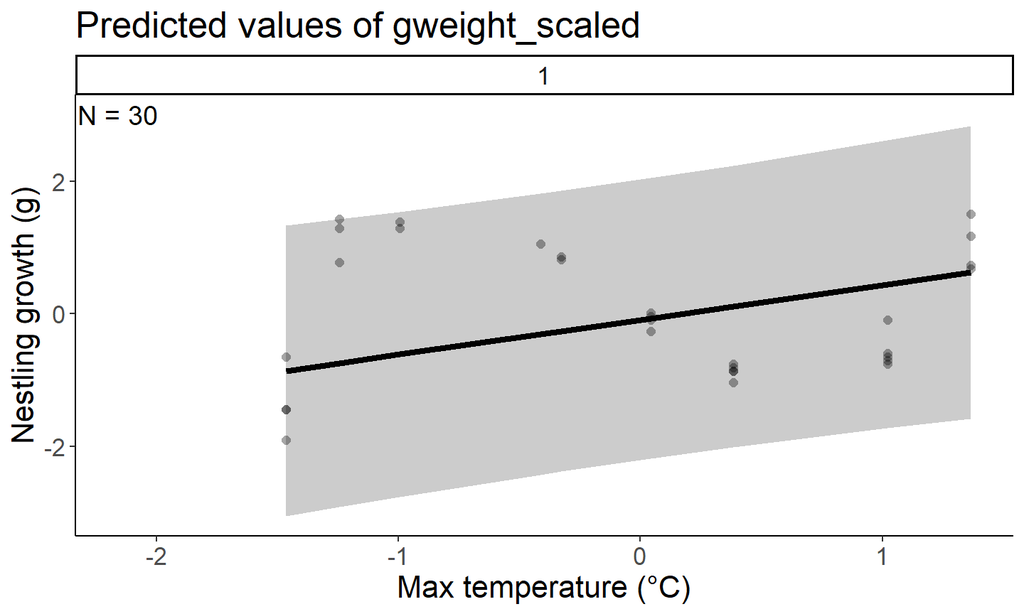

## Predicted growth across temp and habitat: TRES, grassland

For original model with min temp, squared min temp helps:

| model | npar | AIC | BIC | logLik | deviance | Chisq | Df | Pr(>Chisq) |
| --- | --- | --- | --- | --- | --- | --- | --- | --- |
| no sq | 9 | 472.9050 | 501.9850 | -227.4525 | 454.9050 | NA | NA | NA |
| no min sq | 10 | 473.7668 | 506.0778 | -226.8834 | 453.7668 | 1.138243 | 1 | 0.28602383 |
| sq max and min | 11 | 472.0875 | 507.6297 | -225.0438 | 450.0875 | 3.679210 | 1 | 0.05509496 |

| model | npar | AIC | BIC | logLik | deviance | Chisq | Df | Pr(>Chisq) |
| --- | --- | --- | --- | --- | --- | --- | --- | --- |
| no sq | 9 | 472.9050 | 501.9850 | -227.4525 | 454.9050 | NA | NA | NA |
| no max sq | 10 | 470.8399 | 503.1510 | -225.4199 | 450.8399 | 4.0651207 | 1 | 0.04377756 |
| sq max and min | 11 | 472.0875 | 507.6297 | -225.0438 | 450.0875 | 0.7523321 | 1 | 0.38573888 |

```
## Linear mixed model fit by REML. t-tests use Satterthwaite's method [
## lmerModLmerTest]
## Formula: gweight_scaled ~ meanmaxtempI_scaled + poly(meanmintempI_scaled,
##     2) + age_scaled + juliandate_scaled + (1 | year) + (1 | site/attempt_id)
##    Data:
## dplyr::filter(g, habitat == "Grassland", Species == "TRES", !is.na(meanmaxtempI)) %>%
##     mutate(across(c(gweight, meanmaxtempI, meanmintempI, juliandate,
##         brood_size, age), ~scale(.x)[, 1], .names = "{.col}_scaled"),
##         meanmaxtempI_scaled_sq = meanmaxtempI_scaled * meanmaxtempI_scaled)
##
## REML criterion at convergence: 453
##
## Scaled residuals:
##      Min       1Q   Median       3Q      Max
## -3.10873 -0.46070  0.05351  0.51694  2.30928
##
## Random effects:
##  Groups          Name        Variance  Std.Dev.
##  attempt_id:site (Intercept) 8.348e-01 9.137e-01
##  site            (Intercept) 9.891e-10 3.145e-05
##  year            (Intercept) 2.252e-01 4.746e-01
##  Residual                    4.418e-01 6.647e-01
## Number of obs: 187, groups:  attempt_id:site, 33; site, 3; year, 3
##
## Fixed effects:
##                                Estimate Std. Error        df t value Pr(>|t|)
## (Intercept)                     0.18500    0.33185   1.50453   0.557  0.64875
## meanmaxtempI_scaled             0.36525    0.13500  53.60723   2.706  0.00912
## poly(meanmintempI_scaled, 2)1  -0.65951    2.50332  36.17618  -0.263  0.79370
## poly(meanmintempI_scaled, 2)2  -3.93956    1.53275 124.87712  -2.570  0.01134
## age_scaled                     -0.33946    0.08107 148.48074  -4.187 4.82e-05
## juliandate_scaled              -0.37435    0.19870  26.57196  -1.884  0.07056
##
## (Intercept)
## meanmaxtempI_scaled           **
## poly(meanmintempI_scaled, 2)1
## poly(meanmintempI_scaled, 2)2 *
## age_scaled                    ***
## juliandate_scaled             .
## ---
## Signif. codes:  0 '***' 0.001 '**' 0.01 '*' 0.05 '.' 0.1 ' ' 1
##
## Correlation of Fixed Effects:
##             (Intr) mnmxI_ p(I_,2)1 p(I_,2)2 ag_scl
## mnmxtmpI_sc -0.005
## ply(mI_,2)1  0.013 -0.395
## ply(mI_,2)2 -0.037 -0.028 -0.132
## age_scaled  -0.037  0.337 -0.271    0.312
## julndt_scld -0.098  0.040 -0.446    0.195   -0.031
## optimizer (nloptwrap) convergence code: 0 (OK)
## boundary (singular) fit: see help('isSingular')
```

Adding squared min when you already have squared max does add some fit, but adding squared max when you have squared min does not add fit. So the squared min term is more important in grassland than the squared max term.

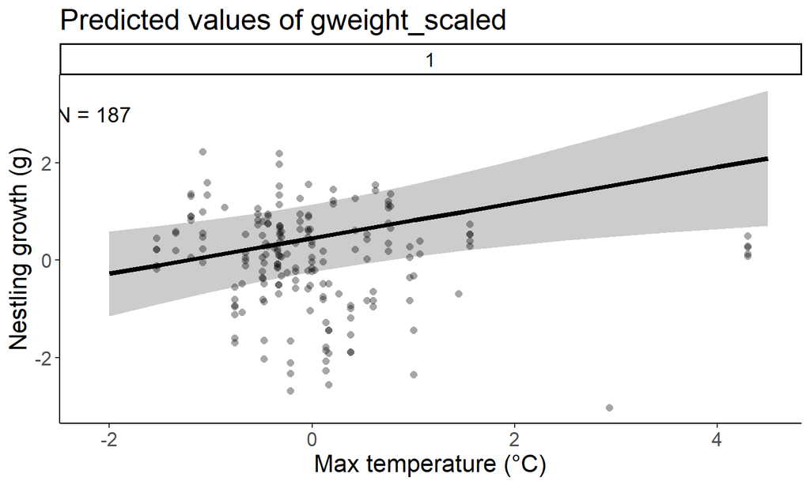

## Predicted growth across temp and habitat: TRES, grassland

For updated model based on DAG, squared term also does not help fit:

| model | npar | AIC | BIC | logLik | deviance | Chisq | Df | Pr(>Chisq) |
| --- | --- | --- | --- | --- | --- | --- | --- | --- |
| no sq | 8 | 471.0248 | 496.8737 | -227.5124 | 455.0248 | NA | NA | NA |
| sq max temp | 9 | 471.8074 | 500.8874 | -226.9037 | 453.8074 | 1.217366 | 1 | 0.2698782 |

```
## Linear mixed model fit by REML. t-tests use Satterthwaite's method [
## lmerModLmerTest]
## Formula:
## gweight_scaled ~ meanmaxtempI_scaled + age_scaled + juliandate_scaled +
##     (1 | year) + (1 | site/attempt_id)
##    Data:
## dplyr::filter(g, habitat == "Grassland", Species == "TRES", !is.na(meanmaxtempI)) %>%
##     mutate(across(c(gweight, meanmaxtempI, meanmintempI, juliandate,
##         brood_size, age), ~scale(.x)[, 1], .names = "{.col}_scaled"),
##         meanmaxtempI_scaled_sq = meanmaxtempI_scaled * meanmaxtempI_scaled)
##
## REML criterion at convergence: 464.8
##
## Scaled residuals:
##     Min      1Q  Median      3Q     Max
## -3.4114 -0.4634  0.0571  0.5452  2.5462
##
## Random effects:
##  Groups          Name        Variance  Std.Dev.
##  attempt_id:site (Intercept) 6.216e-01 7.884e-01
##  site            (Intercept) 9.276e-11 9.631e-06
##  year            (Intercept) 3.820e-02 1.954e-01
##  Residual                    4.791e-01 6.922e-01
## Number of obs: 187, groups:  attempt_id:site, 33; site, 3; year, 3
##
## Fixed effects:
##                      Estimate Std. Error        df t value Pr(>|t|)
## (Intercept)           0.09006    0.19359   0.86391   0.465 0.732096
## meanmaxtempI_scaled   0.24456    0.11888  80.67849   2.057 0.042893 *
## age_scaled           -0.29311    0.07523 178.19316  -3.896 0.000138 ***
## juliandate_scaled    -0.25714    0.15447  23.43576  -1.665 0.109286
## ---
## Signif. codes:  0 '***' 0.001 '**' 0.01 '*' 0.05 '.' 0.1 ' ' 1
##
## Correlation of Fixed Effects:
##             (Intr) mnmxI_ ag_scl
## mnmxtmpI_sc -0.013
## age_scaled  -0.054  0.291
## julndt_scld -0.110 -0.172 -0.205
## optimizer (nloptwrap) convergence code: 0 (OK)
## boundary (singular) fit: see help('isSingular')
```

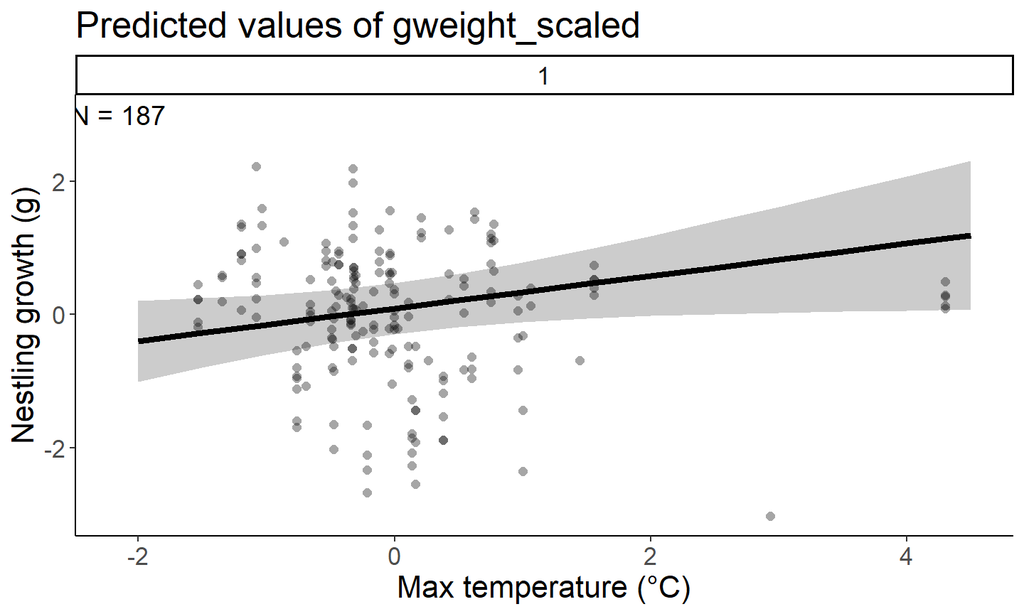

## Predicted growth across temp and habitat: TRES, row crop

For original model with min temp:

| model | npar | AIC | BIC | logLik | deviance | Chisq | Df | Pr(>Chisq) |
| --- | --- | --- | --- | --- | --- | --- | --- | --- |
| no sq | 9 | 230.3214 | 253.4938 | -106.16070 | 212.3214 | NA | NA | NA |
| no min sq | 10 | 223.2260 | 248.9731 | -101.61300 | 203.2260 | 9.095402 | 1 | 0.002562529 |
| sq max and min | 11 | 218.1377 | 246.4595 | -98.06885 | 196.1377 | 7.088314 | 1 | 0.007758819 |

| model | npar | AIC | BIC | logLik | deviance | Chisq | Df | Pr(>Chisq) |
| --- | --- | --- | --- | --- | --- | --- | --- | --- |
| no sq | 9 | 230.3214 | 253.4938 | -106.16070 | 212.3214 | NA | NA | NA |
| no max sq | 10 | 219.4845 | 245.2316 | -99.74226 | 199.4845 | 12.836880 | 1 | 0.0003398538 |
| sq max and min | 11 | 218.1377 | 246.4595 | -98.06885 | 196.1377 | 3.346836 | 1 | 0.0673343123 |

```
## Linear mixed model fit by REML. t-tests use Satterthwaite's method [
## lmerModLmerTest]
## Formula: gweight_scaled ~ meanmaxtempI_scaled + poly(meanmintempI_scaled,
##     2) + age_scaled + juliandate_scaled + (1 | year) + (1 | site/attempt_id)
##    Data:
## dplyr::filter(g, habitat == "Row crop", Species == "TRES", !is.na(meanmaxtempI)) %>%
##     mutate(across(c(gweight, meanmaxtempI, meanmintempI, juliandate,
##         brood_size, age), ~scale(.x)[, 1], .names = "{.col}_scaled"),
##         meanmaxtempI_scaled_sq = meanmaxtempI_scaled * meanmaxtempI_scaled)
##
## REML criterion at convergence: 203.5
##
## Scaled residuals:
##     Min      1Q  Median      3Q     Max
## -3.7055 -0.5326  0.0165  0.4701  2.5209
##
## Random effects:
##  Groups          Name        Variance  Std.Dev.
##  attempt_id:site (Intercept) 7.078e-01 8.413e-01
##  site            (Intercept) 1.127e-10 1.062e-05
##  year            (Intercept) 7.760e-10 2.786e-05
##  Residual                    3.087e-01 5.556e-01
## Number of obs: 97, groups:  attempt_id:site, 18; site, 3; year, 3
##
## Fixed effects:
##                               Estimate Std. Error       df t value Pr(>|t|)
## (Intercept)                    0.17077    0.21029 13.54874   0.812 0.430781
## meanmaxtempI_scaled           -0.71680    0.18585 25.26246  -3.857 0.000705 ***
## poly(meanmintempI_scaled, 2)1  1.14720    2.33379 17.41313   0.492 0.629168
## poly(meanmintempI_scaled, 2)2  3.36414    0.91536 87.88546   3.675 0.000408 ***
## age_scaled                    -0.35719    0.11252 59.66059  -3.175 0.002375 **
## juliandate_scaled              0.09132    0.19165 14.71274   0.477 0.640709
## ---
## Signif. codes:  0 '***' 0.001 '**' 0.01 '*' 0.05 '.' 0.1 ' ' 1
##
## Correlation of Fixed Effects:
##             (Intr) mnmxI_ p(I_,2)1 p(I_,2)2 ag_scl
## mnmxtmpI_sc  0.007
## ply(mI_,2)1  0.002 -0.863
## ply(mI_,2)2 -0.033  0.349 -0.275
## age_scaled  -0.061  0.292 -0.496    0.181
## julndt_scld -0.084 -0.063 -0.015    0.058   -0.161
## optimizer (nloptwrap) convergence code: 0 (OK)
## boundary (singular) fit: see help('isSingular')
```

Squared min is more important than squared max for fit, but when squared max is added to squared min, it’s marginally significantly better?

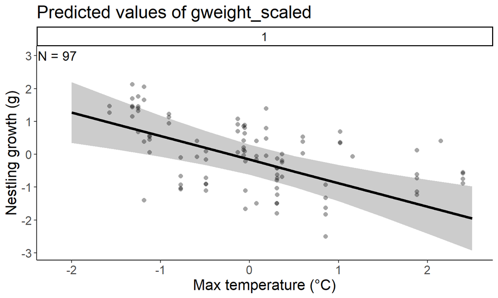

## Predicted growth across temp and habitat: TRES, row crop

For updated model based on DAG, squared term is supported:

| model | npar | AIC | BIC | logLik | deviance | Chisq | Df | Pr(>Chisq) |
| --- | --- | --- | --- | --- | --- | --- | --- | --- |
| no sq | 8 | 229.9958 | 250.5935 | -106.9979 | 213.9958 | NA | NA | NA |
| sq max temp | 9 | 222.3997 | 245.5721 | -102.1998 | 204.3997 | 9.596185 | 1 | 0.001949821 |

```
## Linear mixed model fit by REML. t-tests use Satterthwaite's method [
## lmerModLmerTest]
## Formula: gweight_scaled ~ poly(meanmaxtempI_scaled, 2) + age_scaled +
##     juliandate_scaled + (1 | year) + (1 | site/attempt_id)
##    Data:
## dplyr::filter(g, habitat == "Row crop", Species == "TRES", !is.na(meanmaxtempI)) %>%
##     mutate(across(c(gweight, meanmaxtempI, meanmintempI, juliandate,
##         brood_size, age), ~scale(.x)[, 1], .names = "{.col}_scaled"),
##         meanmaxtempI_scaled_sq = meanmaxtempI_scaled * meanmaxtempI_scaled)
##
## REML criterion at convergence: 207.8
##
## Scaled residuals:
##     Min      1Q  Median      3Q     Max
## -3.4584 -0.6221  0.0966  0.5327  2.4829
##
## Random effects:
##  Groups          Name        Variance Std.Dev.
##  attempt_id:site (Intercept) 0.5557   0.7455
##  site            (Intercept) 0.0000   0.0000
##  year            (Intercept) 0.0000   0.0000
##  Residual                    0.3390   0.5823
## Number of obs: 97, groups:  attempt_id:site, 18; site, 3; year, 3
##
## Fixed effects:
##                               Estimate Std. Error       df t value Pr(>|t|)
## (Intercept)                    0.18174    0.18967 13.70102   0.958  0.35458
## poly(meanmaxtempI_scaled, 2)1 -6.94946    0.92069 91.46868  -7.548 3.19e-11 ***
## poly(meanmaxtempI_scaled, 2)2  2.35885    0.75698 83.13139   3.116  0.00252 **
## age_scaled                    -0.23294    0.10458 90.92823  -2.227  0.02838 *
## juliandate_scaled              0.03342    0.17372 15.07582   0.192  0.85000
## ---
## Signif. codes:  0 '***' 0.001 '**' 0.01 '*' 0.05 '.' 0.1 ' ' 1
##
## Correlation of Fixed Effects:
##             (Intr) p(I_,2)1 p(I_,2)2 ag_scl
## ply(mI_,2)1  0.026
## ply(mI_,2)2 -0.012 -0.011
## age_scaled  -0.080 -0.327    0.318
## julndt_scld -0.078 -0.165   -0.008   -0.142
## optimizer (nloptwrap) convergence code: 0 (OK)
## boundary (singular) fit: see help('isSingular')
```

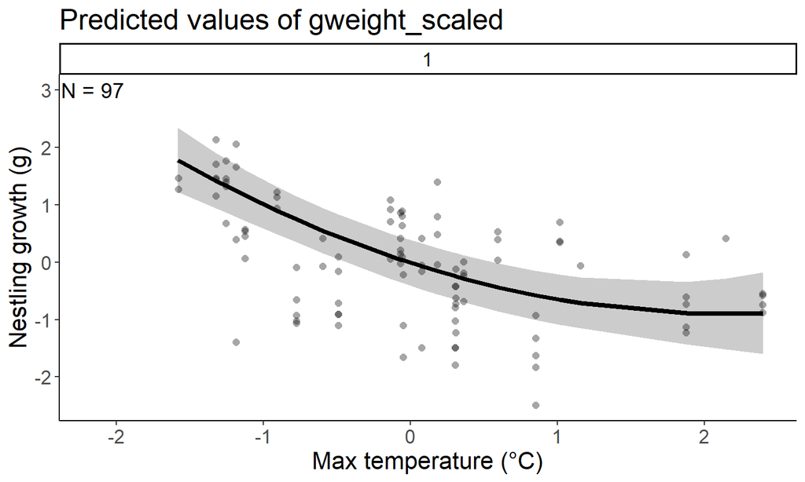

## Conclusions

[output not shown]

## Revisiting nestling cort ~ temp * habitat: WEBL

Base model:

cort_meanI_WEBL <- log(cort_s1) ~ poly(meanmaxtempI_scaled,2,raw = TRUE) * habitat + poly(meanmintempI_scaled,2) * habitat + poly(meanmaxtempI_scaled,2,raw = TRUE) * meanh_scaled + brood_size + age_scaled + juliandate_scaled + (1|year) + (1|site/attempt_id)

Inferential model cort ~ temp * habitat (WEBL):

log(cort_s1) ~ poly(meanmaxtempI_scaled,1,raw = TRUE) * habitat + poly(meanmintempI_scaled,2) * habitat + poly(meanmaxtempI_scaled,2,raw = TRUE) * meanh_scaled + brood_size + age_scaled + juliandate_scaled + (1|year) + (1|site/attempt_id)

Updated model: log(cort_s1) ~ poly(meanmaxtempI_scaled,2) * habitat + age_scaled + juliandate_scaled + (1|year) + (1|site/attempt_id)

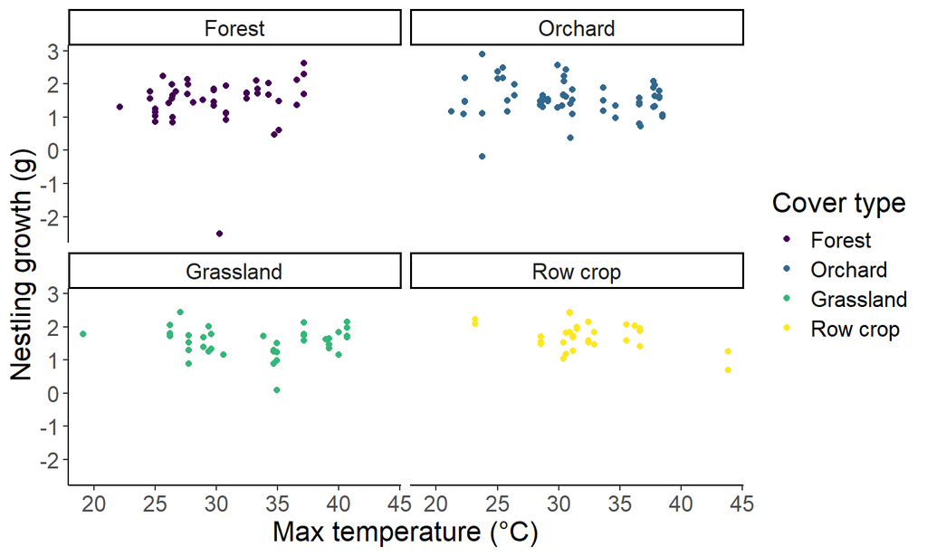

## Cort across temp and habitat: WEBL, forest

For original model with min temp:

| model | npar | AIC | BIC | logLik | deviance | Chisq | Df | Pr(>Chisq) |
| --- | --- | --- | --- | --- | --- | --- | --- | --- |
| no sq | 12 | 59.54281 | 77.85913 | -17.77140 | 35.54281 | NA | NA | NA |
| no min sq | 14 | 62.78929 | 84.15834 | -17.39465 | 34.78929 | 0.75351076 | 2 | 0.6860839 |
| sq max and min | 15 | 64.74718 | 87.64258 | -17.37359 | 34.74718 | 0.04211766 | 1 | 0.8373957 |

| model | npar | AIC | BIC | logLik | deviance | Chisq | Df | Pr(>Chisq) |
| --- | --- | --- | --- | --- | --- | --- | --- | --- |
| no sq | 12 | 59.54281 | 77.85913 | -17.77140 | 35.54281 | NA | NA | NA |
| no max sq | 13 | 61.51158 | 81.35427 | -17.75579 | 35.51158 | 0.03122549 | 1 | 0.8597383 |
| sq max and min | 15 | 64.74718 | 87.64258 | -17.37359 | 34.74718 | 0.76440293 | 2 | 0.6823576 |

```
## Linear mixed model fit by REML. t-tests use Satterthwaite's method [
## lmerModLmerTest]
## Formula:
## log(cort_s1) ~ meanmaxtempI_scaled + meanmintempI_scaled + meanmaxtempI_scaled *
##     meanh_scaled + brood_size + age_scaled + juliandate_scaled +
##     (1 | year) + (1 | site/attempt_id)
##    Data:
## (dplyr::filter(g, habitat == "Forest", Species == "WEBL", !is.na(meanmaxtempI),
##     !is.na(cort_s1)) %>% mutate(across(c(cort_s1, meanmaxtempI,
##     meanmintempI, meanh, cort_s1_mother, age, juliandate), ~scale(.x)[,
##     1], .names = "{.col}_scaled"), meanmaxtempI_scaled_sq = meanmaxtempI_scaled *
##     meanmaxtempI_scaled))
##
## REML criterion at convergence: 51.2
##
## Scaled residuals:
##      Min       1Q   Median       3Q      Max
## -1.55471 -0.56229  0.04283  0.53891  1.94507
##
## Random effects:
##  Groups          Name        Variance Std.Dev.
##  attempt_id:site (Intercept) 0.0000   0.0000
##  site            (Intercept) 0.0000   0.0000
##  year            (Intercept) 3.9094   1.9772
##  Residual                    0.1532   0.3914
## Number of obs: 34, groups:  attempt_id:site, 9; site, 2; year, 2
##
## Fixed effects:
##                                  Estimate Std. Error       df t value Pr(>|t|)
## (Intercept)                       1.23067    1.54011  1.41935   0.799    0.536
## meanmaxtempI_scaled               0.28182    0.19419 25.00326   1.451    0.159
## meanmintempI_scaled              -0.41325    0.24334 25.25276  -1.698    0.102
## meanh_scaled                     -1.58166    0.20918 25.55519  -7.561 5.61e-08
## brood_size                       -0.01997    0.14134 25.04644  -0.141    0.889
## age_scaled                       -0.08069    0.10402 25.00409  -0.776    0.445
## juliandate_scaled                -0.82200    0.16508 25.00779  -4.979 3.93e-05
## meanmaxtempI_scaled:meanh_scaled -0.62550    0.11831 25.28531  -5.287 1.72e-05
##
## (Intercept)
## meanmaxtempI_scaled
## meanmintempI_scaled
## meanh_scaled                     ***
## brood_size
## age_scaled
## juliandate_scaled                ***
## meanmaxtempI_scaled:meanh_scaled ***
## ---
## Signif. codes:  0 '***' 0.001 '**' 0.01 '*' 0.05 '.' 0.1 ' ' 1
##
## Correlation of Fixed Effects:
##             (Intr) mnmxI_ mnmnI_ mnh_sc brd_sz ag_scl jlndt_
## mnmxtmpI_sc -0.077
## mnmntmpI_sc  0.290 -0.433
## meanh_scald  0.100  0.287  0.435
## brood_size  -0.414  0.262 -0.703 -0.184
## age_scaled  -0.038 -0.046  0.078  0.143  0.038
## julndt_scld -0.194 -0.288 -0.489 -0.270  0.471 -0.289
## mnmxtmpI_:_  0.158 -0.066  0.642  0.593 -0.310 -0.049 -0.139
## optimizer (nloptwrap) convergence code: 0 (OK)
## boundary (singular) fit: see help('isSingular')
```

Neither squared temp term adds much to this fit.

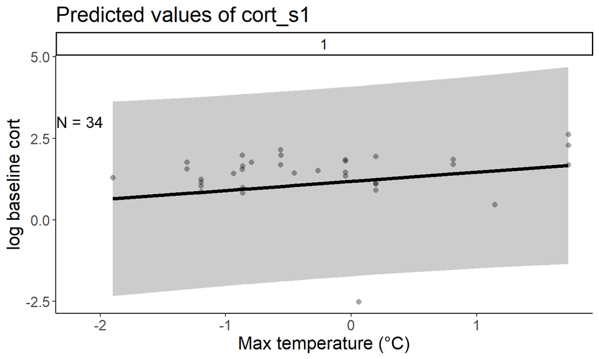

## Cort across temp and habitat: WEBL, forest

For updated model based on DAG, squared temp is not supported:

| model | npar | AIC | BIC | logLik | deviance | Chisq | Df | Pr(>Chisq) |
| --- | --- | --- | --- | --- | --- | --- | --- | --- |
| no sq | 8 | 95.83995 | 110.2932 | -39.91997 | 79.83995 | NA | NA | NA |
| sq max temp | 9 | 95.89558 | 112.1555 | -38.94779 | 77.89558 | 1.944373 | 1 | 0.1631945 |

```
## Linear mixed model fit by REML. t-tests use Satterthwaite's method [
## lmerModLmerTest]
## Formula: log(cort_s1) ~ meanmaxtempI_scaled + age_scaled + juliandate_scaled +
##     (1 | year) + (1 | site/attempt_id)
##    Data:
## dplyr::filter(g, habitat == "Forest", Species == "WEBL", !is.na(meanmaxtempI)) %>%
##     mutate(across(c(gweight, meanmaxtempI, meanmintempI, juliandate,
##         brood_size, age), ~scale(.x)[, 1], .names = "{.col}_scaled"),
##         meanmaxtempI_scaled_sq = meanmaxtempI_scaled * meanmaxtempI_scaled)
##
## REML criterion at convergence: 87.3
##
## Scaled residuals:
##      Min       1Q   Median       3Q      Max
## -2.73384 -0.46273  0.06426  0.50634  1.38544
##
## Random effects:
##  Groups          Name        Variance  Std.Dev.
##  attempt_id:site (Intercept) 4.858e-01 6.970e-01
##  site            (Intercept) 0.000e+00 0.000e+00
##  year            (Intercept) 1.048e-09 3.238e-05
##  Residual                    2.055e-01 4.533e-01
## Number of obs: 45, groups:  attempt_id:site, 13; site, 3; year, 2
##
## Fixed effects:
##                     Estimate Std. Error       df t value Pr(>|t|)
## (Intercept)          1.70687    0.22199 11.49915   7.689 7.29e-06 ***
## meanmaxtempI_scaled  0.56392    0.20090 36.35842   2.807  0.00799 **
## age_scaled          -0.15520    0.08887 40.01215  -1.746  0.08842 .
## juliandate_scaled   -0.60711    0.25674 16.70027  -2.365  0.03044 *
## ---
## Signif. codes:  0 '***' 0.001 '**' 0.01 '*' 0.05 '.' 0.1 ' ' 1
##
## Correlation of Fixed Effects:
##             (Intr) mnmxI_ ag_scl
## mnmxtmpI_sc  0.343
## age_scaled  -0.040 -0.117
## julndt_scld -0.276 -0.581 -0.188
## optimizer (nloptwrap) convergence code: 0 (OK)
## boundary (singular) fit: see help('isSingular')
```

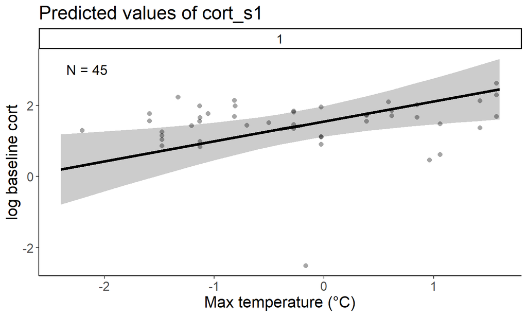

## Cort across temp and habitat: WEBL, orchard

For original model with min temp:

| model | npar | AIC | BIC | logLik | deviance | Chisq | Df | Pr(>Chisq) |
| --- | --- | --- | --- | --- | --- | --- | --- | --- |
| no sq | 12 | 75.36664 | 89.50329 | -25.68332 | 51.36664 | NA | NA | NA |
| no min sq | 14 | 76.68356 | 93.17631 | -24.34178 | 48.68356 | 2.683086 | 2 | 0.2614420 |
| sq max and min | 15 | 75.51959 | 93.19040 | -22.75979 | 45.51959 | 3.163966 | 1 | 0.0752801 |

| model | npar | AIC | BIC | logLik | deviance | Chisq | Df | Pr(>Chisq) |
| --- | --- | --- | --- | --- | --- | --- | --- | --- |
| no sq | 12 | 75.36664 | 89.50329 | -25.68332 | 51.36664 | NA | NA | NA |
| no max sq | 13 | 75.36156 | 90.67626 | -24.68078 | 49.36156 | 2.005082 | 1 | 0.1567728 |
| sq max and min | 15 | 75.51959 | 93.19040 | -22.75979 | 45.51959 | 3.841969 | 2 | 0.1464627 |

```
## Linear mixed model fit by REML. t-tests use Satterthwaite's method [
## lmerModLmerTest]
## Formula:
## cort_s1_scaled ~ poly(meanmaxtempI_scaled, 2, raw = TRUE) + poly(meanmintempI_scaled,
##     2) + poly(meanmaxtempI_scaled, 2, raw = TRUE) * meanh_scaled +
##     brood_size + age_scaled + juliandate_scaled + (1 | year) +
##     (1 | site/attempt_id)
##    Data:
## (dplyr::filter(g, habitat == "Orchard", Species == "WEBL", !is.na(meanmaxtempI),
##     !is.na(cort_s1)) %>% mutate(across(c(cort_s1, meanmaxtempI,
##     meanmintempI, meanh, cort_s1_mother, age, juliandate), ~scale(.x)[,
##     1], .names = "{.col}_scaled"), meanmaxtempI_scaled_sq = meanmaxtempI_scaled *
##     meanmaxtempI_scaled))
##
## REML criterion at convergence: 35
##
## Scaled residuals:
##     Min      1Q  Median      3Q     Max
## -1.8334 -0.2288  0.0000  0.2970  1.8334
##
## Random effects:
##  Groups          Name        Variance  Std.Dev.
##  attempt_id:site (Intercept) 0.5086403 0.71319
##  site            (Intercept) 0.0393241 0.19830
##  year            (Intercept) 0.0001312 0.01145
##  Residual                    0.7202744 0.84869
## Number of obs: 24, groups:  attempt_id:site, 9; site, 2; year, 2
##
## Fixed effects:
##                                                          Estimate Std. Error
## (Intercept)                                            -2.785e+01  3.955e+01
## poly(meanmaxtempI_scaled, 2, raw = TRUE)1              -2.133e+01  2.786e+01
## poly(meanmaxtempI_scaled, 2, raw = TRUE)2               1.977e+01  2.310e+01
## poly(meanmintempI_scaled, 2)1                           9.080e+01  1.093e+02
## poly(meanmintempI_scaled, 2)2                          -6.014e+01  7.725e+01
## meanh_scaled                                           -5.035e+00  7.806e+00
## brood_size                                              3.618e+00  5.706e+00
## age_scaled                                              2.803e+00  3.190e+00
## juliandate_scaled                                       7.432e+00  1.263e+01
## poly(meanmaxtempI_scaled, 2, raw = TRUE)1:meanh_scaled -3.566e+00  4.663e+00
```

[output cut: 34 more lines]

```
## age_scaled       -0.990 -0.985            0.990            0.995   -0.996
## julndt_scld      -0.987 -0.988            0.978            0.976   -0.985
## p(I_,2,r=TRUE)1:  0.754  0.776           -0.768           -0.711    0.703
## p(I_,2,r=TRUE)2: -0.998 -0.998            0.999            0.992   -0.993
##                  mnh_sc brd_sz ag_scl jlndt_ p(I_,2,r=TRUE)1:
## pl(I_,2,r=TRUE)1
## pl(I_,2,r=TRUE)2
## ply(mI_,2)1
## ply(mI_,2)2
## meanh_scald
## brood_size       -0.994
## age_scaled       -0.984  0.981
## julndt_scld      -0.995  0.985  0.977
## p(I_,2,r=TRUE)1:  0.745 -0.774 -0.682 -0.706
## p(I_,2,r=TRUE)2: -0.993  0.995  0.989  0.982 -0.771
```

Neither squared term contributes much to this fit.

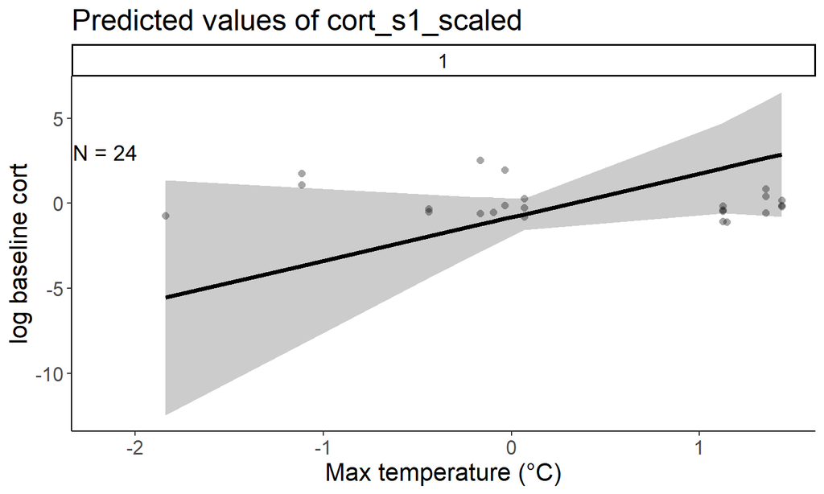

## Cort across temp and habitat: WEBL, orchard

For updated model based on DAG, squared temp is not supported:

| model | npar | AIC | BIC | logLik | deviance | Chisq | Df | Pr(>Chisq) |
| --- | --- | --- | --- | --- | --- | --- | --- | --- |
| no sq | 8 | 181.2501 | 198.0049 | -82.62505 | 165.2501 | NA | NA | NA |
| sq max temp | 9 | 183.0889 | 201.9380 | -82.54445 | 165.0889 | 0.161209 | 1 | 0.6880458 |

```
## Linear mixed model fit by REML. t-tests use Satterthwaite's method [
## lmerModLmerTest]
## Formula:
## cort_s1_scaled ~ meanmaxtempI_scaled + age_scaled + juliandate_scaled +
##     (1 | year) + (1 | site/attempt_id)
##    Data:
## dplyr::filter(g, habitat == "Orchard", Species == "WEBL", !is.na(meanmaxtempI)) %>%
##     mutate(across(c(gweight, meanmaxtempI, meanmintempI, juliandate,
##         brood_size, age, cort_s1), ~scale(.x)[, 1], .names = "{.col}_scaled"),
##         meanmaxtempI_scaled_sq = meanmaxtempI_scaled * meanmaxtempI_scaled)
##
## REML criterion at convergence: 172.4
##
## Scaled residuals:
##     Min      1Q  Median      3Q     Max
## -1.8233 -0.6263 -0.2198  0.3672  3.9444
##
## Random effects:
##  Groups          Name        Variance Std.Dev.
##  attempt_id:site (Intercept) 0.0000   0.0000
##  site            (Intercept) 0.0000   0.0000
##  year            (Intercept) 0.1119   0.3344
##  Residual                    0.9595   0.9795
## Number of obs: 60, groups:  attempt_id:site, 19; site, 2; year, 2
##
## Fixed effects:
##                     Estimate Std. Error       df t value Pr(>|t|)
## (Intercept)          0.03589    0.27920  0.65502   0.129    0.926
## meanmaxtempI_scaled -0.23193    0.25600 55.99740  -0.906    0.369
## age_scaled           0.12112    0.14428 55.66943   0.840    0.405
## juliandate_scaled   -0.06227    0.28234 37.58349  -0.221    0.827
##
## Correlation of Fixed Effects:
##             (Intr) mnmxI_ ag_scl
## mnmxtmpI_sc  0.133
## age_scaled  -0.074 -0.225
## julndt_scld -0.163 -0.858  0.239
## optimizer (nloptwrap) convergence code: 0 (OK)
## boundary (singular) fit: see help('isSingular')
```

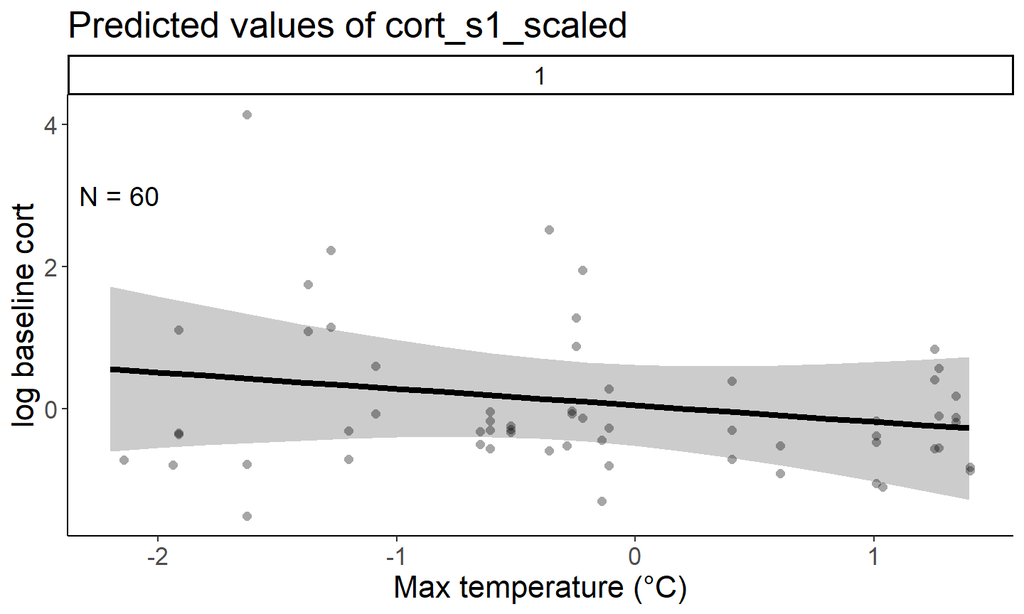

## Cort across temp and habitat: WEBL, grass

For original model with min temp:

| model | npar | AIC | BIC | logLik | deviance | Chisq | Df | Pr(>Chisq) |
| --- | --- | --- | --- | --- | --- | --- | --- | --- |
| no sq | 12 | 90.44055 | 106.42701 | -33.22028 | 66.44055 | NA | NA | NA |
| no min sq | 14 | 77.19576 | 95.84663 | -24.59788 | 49.19576 | 17.2447874 | 2 | 0.0001800288 |
| sq max and min | 15 | 78.62067 | 98.60373 | -24.31033 | 48.62067 | 0.5750981 | 1 | 0.4482401667 |

| model | npar | AIC | BIC | logLik | deviance | Chisq | Df | Pr(>Chisq) |
| --- | --- | --- | --- | --- | --- | --- | --- | --- |
| no sq | 12 | 90.44055 | 106.42701 | -33.22028 | 66.44055 | NA | NA | NA |
| no max sq | 13 | 81.86620 | 99.18485 | -27.93310 | 55.86620 | 10.574356 | 1 | 0.001146672 |
| sq max and min | 15 | 78.62067 | 98.60373 | -24.31033 | 48.62067 | 7.245529 | 2 | 0.026708738 |

```
## Linear mixed model fit by REML. t-tests use Satterthwaite's method [
## lmerModLmerTest]
## Formula:
## cort_s1_scaled ~ poly(meanmaxtempI_scaled, 2, raw = TRUE) + poly(meanmintempI_scaled,
##     2) + poly(meanmaxtempI_scaled, 2, raw = TRUE) * meanh_scaled +
##     brood_size + age_scaled + juliandate_scaled + (1 | year) +
##     (1 | site/attempt_id)
##    Data: (dplyr::filter(g, habitat == "Grassland", Species == "WEBL",
##     !is.na(meanmaxtempI), !is.na(cort_s1)) %>% mutate(across(c(cort_s1,
##     meanmaxtempI, meanmintempI, meanh, cort_s1_mother, age, juliandate),
##     ~scale(.x)[, 1], .names = "{.col}_scaled"), meanmaxtempI_scaled_sq = meanmaxtempI_scaled *
##     meanmaxtempI_scaled))
##
## REML criterion at convergence: 52.2
##
## Scaled residuals:
##      Min       1Q   Median       3Q      Max
## -1.33105 -0.54722 -0.04368  0.40889  1.45979
##
## Random effects:
##  Groups          Name        Variance Std.Dev.
##  attempt_id:site (Intercept) 0.81409  0.9023
##  site            (Intercept) 0.23127  0.4809
##  year            (Intercept) 0.04818  0.2195
##  Residual                    0.54748  0.7399
## Number of obs: 28, groups:  attempt_id:site, 7; site, 3; year, 2
##
## Fixed effects:
##                                                          Estimate Std. Error
## (Intercept)                                            -6.802e+00  8.177e+00
## poly(meanmaxtempI_scaled, 2, raw = TRUE)1              -5.902e-01  2.754e+00
## poly(meanmaxtempI_scaled, 2, raw = TRUE)2               2.364e+00  2.225e+00
## poly(meanmintempI_scaled, 2)1                          -7.032e+00  1.151e+01
## poly(meanmintempI_scaled, 2)2                           2.139e+00  5.990e+00
## meanh_scaled                                           -6.271e-01  1.109e+00
## brood_size                                              1.528e+00  1.788e+00
## age_scaled                                              6.311e-01  5.070e-01
## juliandate_scaled                                      -5.789e-02  9.255e-01
## poly(meanmaxtempI_scaled, 2, raw = TRUE)1:meanh_scaled  2.582e+00  2.797e+00
## poly(meanmaxtempI_scaled, 2, raw = TRUE)2:meanh_scaled -2.953e-01  9.726e-01
```

[output cut: 36 more lines]

```
## p(I_,2,r=TRUE)2:  0.095  0.952           -0.440           -0.726    0.503
##                  mnh_sc brd_sz ag_scl jlndt_ p(I_,2,r=TRUE)1:
## pl(I_,2,r=TRUE)1
## pl(I_,2,r=TRUE)2
## ply(mI_,2)1
## ply(mI_,2)2
## meanh_scald
## brood_size       -0.798
## age_scaled        0.047 -0.092
## julndt_scld      -0.443  0.378  0.309
## p(I_,2,r=TRUE)1: -0.785  0.855 -0.443  0.073
## p(I_,2,r=TRUE)2:  0.328 -0.138  0.571 -0.187 -0.416
## optimizer (nloptwrap) convergence code: 0 (OK)
## unable to evaluate scaled gradient
## Model failed to converge: degenerate  Hessian with 2 negative eigenvalues
```

Max temp contributes to this fit. I dunno, this looks overfit to me.

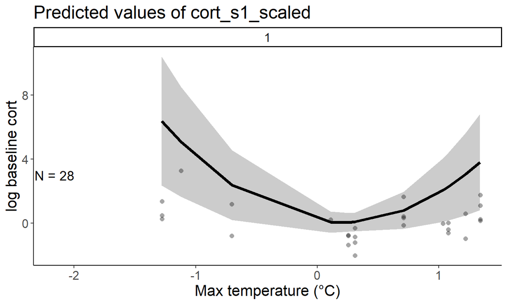

## Cort across temp and habitat: WEBL, grass

For updated model based on DAG, squared temp is marginally supported:

| model | npar | AIC | BIC | logLik | deviance | Chisq | Df | Pr(>Chisq) |
| --- | --- | --- | --- | --- | --- | --- | --- | --- |
| no sq | 8 | 115.9177 | 129.2262 | -49.95886 | 99.91771 | NA | NA | NA |
| sq max temp | 9 | 114.5356 | 129.5076 | -48.26778 | 96.53556 | 3.382156 | 1 | 0.06590581 |

```
## Linear mixed model fit by REML. t-tests use Satterthwaite's method [
## lmerModLmerTest]
## Formula: cort_s1_scaled ~ poly(meanmaxtempI_scaled, 2) + age_scaled +
##     juliandate_scaled + (1 | year) + (1 | site/attempt_id)
##    Data:
## dplyr::filter(g, habitat == "Grassland", Species == "WEBL", !is.na(meanmaxtempI)) %>%
##     mutate(across(c(gweight, meanmaxtempI, meanmintempI, juliandate,
##         brood_size, age, cort_s1), ~scale(.x)[, 1], .names = "{.col}_scaled"),
##         meanmaxtempI_scaled_sq = meanmaxtempI_scaled * meanmaxtempI_scaled)
##
## REML criterion at convergence: 93.1
##
## Scaled residuals:
##     Min      1Q  Median      3Q     Max
## -1.6490 -0.5796 -0.1492  0.5168  1.9079
##
## Random effects:
##  Groups          Name        Variance Std.Dev.
##  attempt_id:site (Intercept) 0.3619   0.6016
##  site            (Intercept) 0.4922   0.7016
##  year            (Intercept) 0.2450   0.4950
##  Residual                    0.5153   0.7178
## Number of obs: 39, groups:  attempt_id:site, 10; site, 3; year, 2
##
## Fixed effects:
##                               Estimate Std. Error      df t value Pr(>|t|)
## (Intercept)                     0.2841     0.5965  1.6375   0.476  0.68974
## poly(meanmaxtempI_scaled, 2)1  -1.8579     2.5546 16.5019  -0.727  0.47725
## poly(meanmaxtempI_scaled, 2)2   2.7814     1.5233 27.3947   1.826  0.07878 .
## age_scaled                      0.4653     0.1497 28.7195   3.109  0.00421 **
## juliandate_scaled              -0.6235     0.3051  7.1741  -2.043  0.07933 .
## ---
## Signif. codes:  0 '***' 0.001 '**' 0.01 '*' 0.05 '.' 0.1 ' ' 1
##
## Correlation of Fixed Effects:
##             (Intr) p(I_,2)1 p(I_,2)2 ag_scl
## ply(mI_,2)1  0.070
## ply(mI_,2)2  0.005 -0.144
## age_scaled   0.007 -0.211    0.056
## julndt_scld -0.030 -0.377    0.107   -0.238
## optimizer (nloptwrap) convergence code: 0 (OK)
## Model failed to converge with max|grad| = 0.00399984 (tol = 0.002, component 1)
```

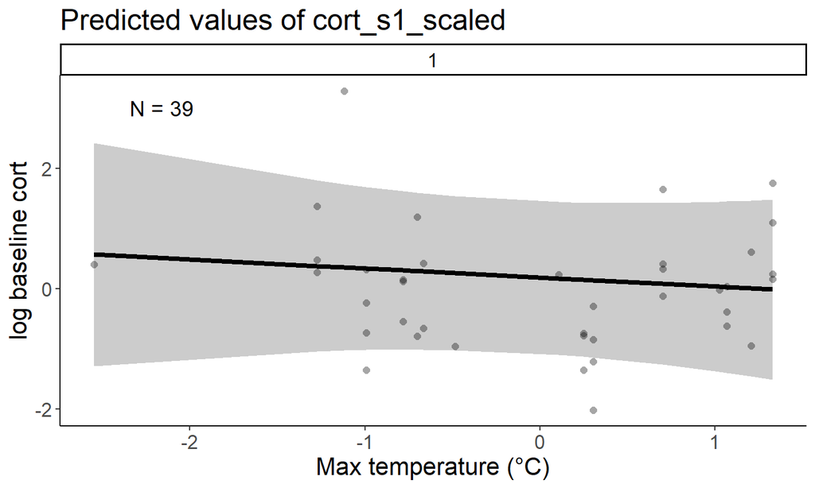

## Cort across temp and habitat: WEBL, rc

For original model with min temp:

| model | npar | AIC | BIC | logLik | deviance | Chisq | Df | Pr(>Chisq) |
| --- | --- | --- | --- | --- | --- | --- | --- | --- |
| no sq | 12 | 90.03779 | 107.2456 | -33.01889 | 66.03779 | NA | NA | NA |
| no min sq | 14 | 84.94426 | 105.0201 | -28.47213 | 56.94426 | 9.093530 | 2 | 0.01060145 |
| sq max and min | 15 | 83.70997 | 105.2198 | -26.85499 | 53.70997 | 3.234285 | 1 | 0.07211176 |

| model | npar | AIC | BIC | logLik | deviance | Chisq | Df | Pr(>Chisq) |
| --- | --- | --- | --- | --- | --- | --- | --- | --- |
| no sq | 12 | 90.03779 | 107.2456 | -33.01889 | 66.03779 | NA | NA | NA |
| no max sq | 13 | 83.16882 | 101.8107 | -28.58441 | 57.16882 | 8.868965 | 1 | 0.002900595 |
| sq max and min | 15 | 83.70997 | 105.2198 | -26.85499 | 53.70997 | 3.458850 | 2 | 0.177386391 |

```
## Linear mixed model fit by REML. t-tests use Satterthwaite's method [
## lmerModLmerTest]
## Formula:
## cort_s1_scaled ~ poly(meanmaxtempI_scaled, 2, raw = TRUE) + poly(meanmintempI_scaled,
##     2) + poly(meanmaxtempI_scaled, 2, raw = TRUE) * meanh_scaled +
##     brood_size + age_scaled + juliandate_scaled + (1 | year) +
##     (1 | site/attempt_id)
##    Data:
## (dplyr::filter(g, habitat == "Row crop", Species == "WEBL", !is.na(meanmaxtempI),
##     !is.na(cort_s1)) %>% mutate(across(c(cort_s1, meanmaxtempI,
##     meanmintempI, meanh, cort_s1_mother, age, juliandate), ~scale(.x)[,
##     1], .names = "{.col}_scaled"), meanmaxtempI_scaled_sq = meanmaxtempI_scaled *
##     meanmaxtempI_scaled))
##
## REML criterion at convergence: 64.4
##
## Scaled residuals:
##      Min       1Q   Median       3Q      Max
## -1.96078 -0.53984  0.02201  0.51229  1.78520
##
## Random effects:
##  Groups          Name        Variance Std.Dev.
##  attempt_id:site (Intercept) 0.0000   0.0000
##  site            (Intercept) 0.0000   0.0000
##  year            (Intercept) 0.0000   0.0000
##  Residual                    0.5132   0.7164
## Number of obs: 31, groups:  attempt_id:site, 10; site, 3; year, 2
##
## Fixed effects:
##                                                        Estimate Std. Error
## (Intercept)                                             -0.7835     2.0044
## poly(meanmaxtempI_scaled, 2, raw = TRUE)1                0.6383     0.4178
## poly(meanmaxtempI_scaled, 2, raw = TRUE)2                0.5923     0.4918
## poly(meanmintempI_scaled, 2)1                            2.4950     3.0363
## poly(meanmintempI_scaled, 2)2                            3.5231     2.3756
## meanh_scaled                                            -0.3135     0.4459
## brood_size                                               0.1789     0.4384
## age_scaled                                              -0.1906     0.2947
## juliandate_scaled                                       -0.5337     0.3933
## poly(meanmaxtempI_scaled, 2, raw = TRUE)1:meanh_scaled  -0.1773     0.5082
```

[output cut: 24 more lines]

```
## p(I_,2,r=TRUE)1: -0.014  0.429           -0.699           -0.515    0.473
## p(I_,2,r=TRUE)2: -0.067 -0.211            0.921            0.604   -0.424
##                  mnh_sc brd_sz ag_scl jlndt_ p(I_,2,r=TRUE)1:
## pl(I_,2,r=TRUE)1
## pl(I_,2,r=TRUE)2
## ply(mI_,2)1
## ply(mI_,2)2
## meanh_scald
## brood_size       -0.305
## age_scaled        0.354  0.018
## julndt_scld       0.355  0.155 -0.369
## p(I_,2,r=TRUE)1:  0.705  0.057  0.149  0.489
## p(I_,2,r=TRUE)2: -0.841  0.013 -0.439 -0.474 -0.853
## optimizer (nloptwrap) convergence code: 0 (OK)
## boundary (singular) fit: see help('isSingular')
```

Squared min temp contributes to this fit, but I don’t think it really fits the data very well. May be a case of “getting the priors back”

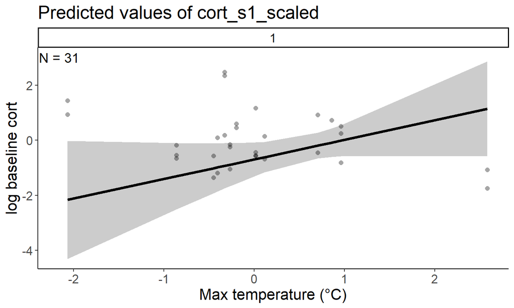

## Cort across temp and habitat: WEBL, rc

For updated model based on DAG, squared temp is not supported:

| model | npar | AIC | BIC | logLik | deviance | Chisq | Df | Pr(>Chisq) |
| --- | --- | --- | --- | --- | --- | --- | --- | --- |
| no sq | 8 | 92.03495 | 103.5069 | -38.01748 | 76.03495 | NA | NA | NA |
| sq max temp | 9 | 93.87667 | 106.7826 | -37.93834 | 75.87667 | 0.1582802 | 1 | 0.6907449 |

```
## Linear mixed model fit by REML. t-tests use Satterthwaite's method [
## lmerModLmerTest]
## Formula:
## cort_s1_scaled ~ meanmaxtempI_scaled + age_scaled + juliandate_scaled +
##     (1 | year) + (1 | site/attempt_id)
##    Data:
## dplyr::filter(g, habitat == "Row crop", Species == "WEBL", !is.na(meanmaxtempI)) %>%
##     mutate(across(c(gweight, meanmaxtempI, meanmintempI, juliandate,
##         brood_size, age, cort_s1), ~scale(.x)[, 1], .names = "{.col}_scaled"),
##         meanmaxtempI_scaled_sq = meanmaxtempI_scaled * meanmaxtempI_scaled)
##
## REML criterion at convergence: 80.4
##
## Scaled residuals:
##     Min      1Q  Median      3Q     Max
## -1.3942 -0.6733  0.1051  0.3946  1.7877
##
## Random effects:
##  Groups          Name        Variance Std.Dev.
##  attempt_id:site (Intercept) 0.3111   0.5578
##  site            (Intercept) 0.0000   0.0000
##  year            (Intercept) 0.3572   0.5976
##  Residual                    0.5171   0.7191
## Number of obs: 31, groups:  attempt_id:site, 10; site, 3; year, 2
##
## Fixed effects:
##                     Estimate Std. Error       df t value Pr(>|t|)
## (Intercept)          0.09262    0.48547  0.87814   0.191  0.88318
## meanmaxtempI_scaled -0.04244    0.20116 17.36706  -0.211  0.83535
## age_scaled           0.65501    0.22764 25.42533   2.877  0.00801 **
## juliandate_scaled   -0.27208    0.24891  7.85066  -1.093  0.30677
## ---
## Signif. codes:  0 '***' 0.001 '**' 0.01 '*' 0.05 '.' 0.1 ' ' 1
##
## Correlation of Fixed Effects:
##             (Intr) mnmxI_ ag_scl
## mnmxtmpI_sc  0.011
## age_scaled  -0.005  0.381
## julndt_scld  0.064 -0.491 -0.356
## optimizer (nloptwrap) convergence code: 0 (OK)
## boundary (singular) fit: see help('isSingular')
```

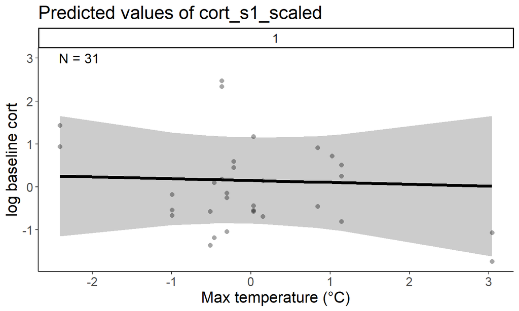

## Conclusions

Some concerns with overfitting

[output not shown]

## Revisiting nestling cort ~ temp * habitat: TRES

Base model:

cort_meanI_TRES <- log(cort_s1) ~ poly(meanmaxtempI_scaled,2,raw = TRUE) * habitat + poly(meanmintempI_scaled,2) * habitat + poly(meanmaxtempI_scaled,2,raw = TRUE) * meanh_scaled + brood_size + age_scaled + juliandate_scaled + (1|year) + (1|site/attempt_id)

Inferential model cort ~ temp * habitat (TRES):

log(cort_s1) ~ habitat + poly(meanmaxtempI_scaled,2,raw = TRUE) + poly(meanmintempI_scaled,2) * habitat + poly(meanmaxtempI_scaled,2,raw = TRUE) * meanh_scaled + brood_size + age_scaled + juliandate_scaled + (1|year) + (1|site/attempt_id)

Updated model: log(cort_s1) ~ poly(meanmaxtempI_scaled,2) * habitat + age_scaled + juliandate_scaled + (1|year) + (1|site/attempt_id)

## Raw cort by temp and habitat, for referencing while looking at the modeling results

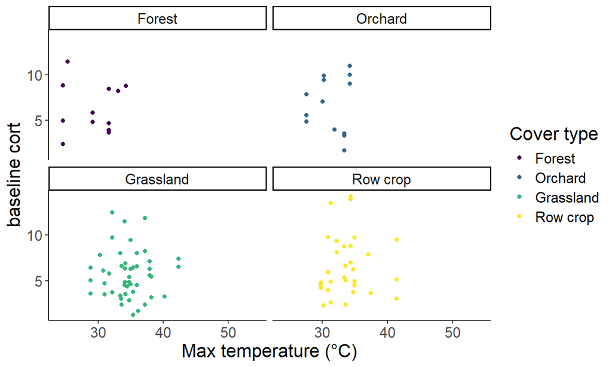

## Cort across temp and habitat: TRES, forest

For original model with min temp:

| model | npar | AIC | BIC | logLik | deviance | Chisq | Df | Pr(>Chisq) |
| --- | --- | --- | --- | --- | --- | --- | --- | --- |
| no sq | 9 | 40.27035 | 43.8514 | -11.13517 | 22.27035 | NA | NA | NA |
| no min sq | 9 | 40.27035 | 43.8514 | -11.13517 | 22.27035 | 0 | 0 | NA |
| sq max and min | 9 | 40.27035 | 43.8514 | -11.13517 | 22.27035 | 0 | 0 | NA |

| model | npar | AIC | BIC | logLik | deviance | Chisq | Df | Pr(>Chisq) |
| --- | --- | --- | --- | --- | --- | --- | --- | --- |
| no sq | 9 | 40.27035 | 43.8514 | -11.13517 | 22.27035 | NA | NA | NA |
| no max sq | 9 | 40.27035 | 43.8514 | -11.13517 | 22.27035 | 0 | 0 | NA |
| sq max and min | 9 | 40.27035 | 43.8514 | -11.13517 | 22.27035 | 0 | 0 | NA |

```
## Linear mixed model fit by REML. t-tests use Satterthwaite's method [
## lmerModLmerTest]
## Formula: cort_s1_scaled ~ meanmaxtempI_scaled + meanmintempI_scaled +
##     meanmaxtempI_scaled * meanh_scaled + brood_size + age_scaled +
##     juliandate_scaled + (1 | year) + (1 | site/attempt_id)
##    Data:
## (dplyr::filter(g, habitat == "Forest", Species == "TRES", !is.na(meanmaxtempI),
##     !is.na(cort_s1)) %>% mutate(across(c(cort_s1, meanmaxtempI,
##     meanmintempI, meanh, cort_s1_mother, age, juliandate), ~scale(.x)[,
##     1], .names = "{.col}_scaled"), meanmaxtempI_scaled_sq = meanmaxtempI_scaled *
##     meanmaxtempI_scaled))
##
## REML criterion at convergence: 22.5
##
## Scaled residuals:
##     Min      1Q  Median      3Q     Max
## -1.2237 -0.3580 -0.1701  0.1058  1.3938
##
## Random effects:
##  Groups          Name        Variance Std.Dev.
##  attempt_id:site (Intercept) 0.725793 0.85193
##  site            (Intercept) 0.003108 0.05575
##  year            (Intercept) 0.015436 0.12424
##  Residual                    0.812886 0.90160
## Number of obs: 11, groups:  attempt_id:site, 5; site, 2; year, 2
##
## Fixed effects:
##                       Estimate Std. Error         df t value Pr(>|t|)
## (Intercept)          1.269e+01  1.613e+01  5.947e-05   0.787        1
## meanmaxtempI_scaled -1.927e+00  2.541e+00  4.171e-05  -0.758        1
## meanmintempI_scaled  3.835e-01  1.288e+00  4.210e-05   0.298        1
## meanh_scaled        -3.759e-01  6.307e-01  6.987e-06  -0.596        1
## brood_size          -2.511e+00  3.181e+00  5.675e-05  -0.789        1
##
## Correlation of Fixed Effects:
##             (Intr) mnmxI_ mnmnI_ mnh_sc
## mnmxtmpI_sc -0.954
## mnmntmpI_sc  0.888 -0.935
## meanh_scald  0.094  0.074 -0.130
## brood_size  -0.999  0.955 -0.886 -0.093
## fit warnings:
## fixed-effect model matrix is rank deficient so dropping 3 columns / coefficients
```

Yikes, not sure which term is responsible, but I think I just don’t have enough data here to estimate anything.

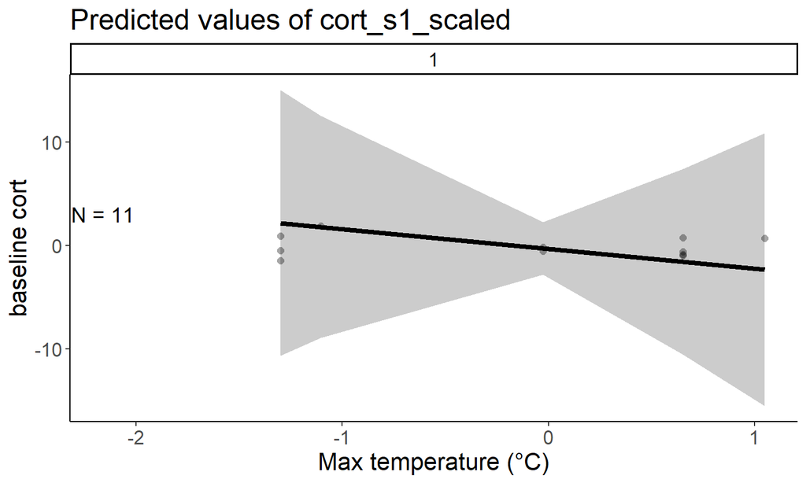

## Cort across temp and habitat: TRES, forest

For updated model based on DAG, squared temp is supported, but the model is super over fit and looks awful:

| model | npar | AIC | BIC | logLik | deviance | Chisq | Df | Pr(>Chisq) |
| --- | --- | --- | --- | --- | --- | --- | --- | --- |
| no sq | 8 | 28.64656 | 32.52581 | -6.323280 | 12.646561 | NA | NA | NA |
| sq max temp | 9 | 25.49163 | 29.85579 | -3.745817 | 7.491634 | 5.154927 | 1 | 0.02318051 |

```
## Linear mixed model fit by REML. t-tests use Satterthwaite's method [
## lmerModLmerTest]
## Formula:
## log(cort_s1) ~ poly(meanmaxtempI_scaled, 2) + age_scaled + juliandate_scaled +
##     (1 | year) + (1 | site/attempt_id)
##    Data:
## dplyr::filter(g, habitat == "Forest", Species == "TRES", !is.na(meanmaxtempI)) %>%
##     mutate(across(c(gweight, meanmaxtempI, meanmintempI, juliandate,
##         brood_size, age), ~scale(.x)[, 1], .names = "{.col}_scaled"),
##         meanmaxtempI_scaled_sq = meanmaxtempI_scaled * meanmaxtempI_scaled)
##
## REML criterion at convergence: 3.8
##
## Scaled residuals:
##      Min       1Q   Median       3Q      Max
## -1.56435 -0.24544 -0.00855  0.17378  1.45062
##
## Random effects:
##  Groups          Name        Variance Std.Dev.
##  attempt_id:site (Intercept) 0.0000   0.0000
##  site            (Intercept) 0.0000   0.0000
##  year            (Intercept) 0.0000   0.0000
##  Residual                    0.1874   0.4329
## Number of obs: 12, groups:  attempt_id:site, 6; site, 3; year, 2
##
## Fixed effects:
##                               Estimate Std. Error       df t value Pr(>|t|)
## (Intercept)                     0.2044     0.8955   7.0000   0.228   0.8260
## poly(meanmaxtempI_scaled, 2)1 -21.6776    12.0386   7.0000  -1.801   0.1148
## poly(meanmaxtempI_scaled, 2)2 -63.4108    32.7179   7.0000  -1.938   0.0938 .
## age_scaled                     -6.3462     3.1771   7.0000  -1.997   0.0859 .
## juliandate_scaled               0.2809     0.2620   7.0000   1.072   0.3193
## ---
## Signif. codes:  0 '***' 0.001 '**' 0.01 '*' 0.05 '.' 0.1 ' ' 1
##
## Correlation of Fixed Effects:
##             (Intr) p(I_,2)1 p(I_,2)2 ag_scl
## ply(mI_,2)1  0.985
## ply(mI_,2)2  0.981  0.993
## age_scaled   0.972  0.988    0.998
## julndt_scld -0.772 -0.788   -0.755   -0.752
## optimizer (nloptwrap) convergence code: 0 (OK)
## boundary (singular) fit: see help('isSingular')
```

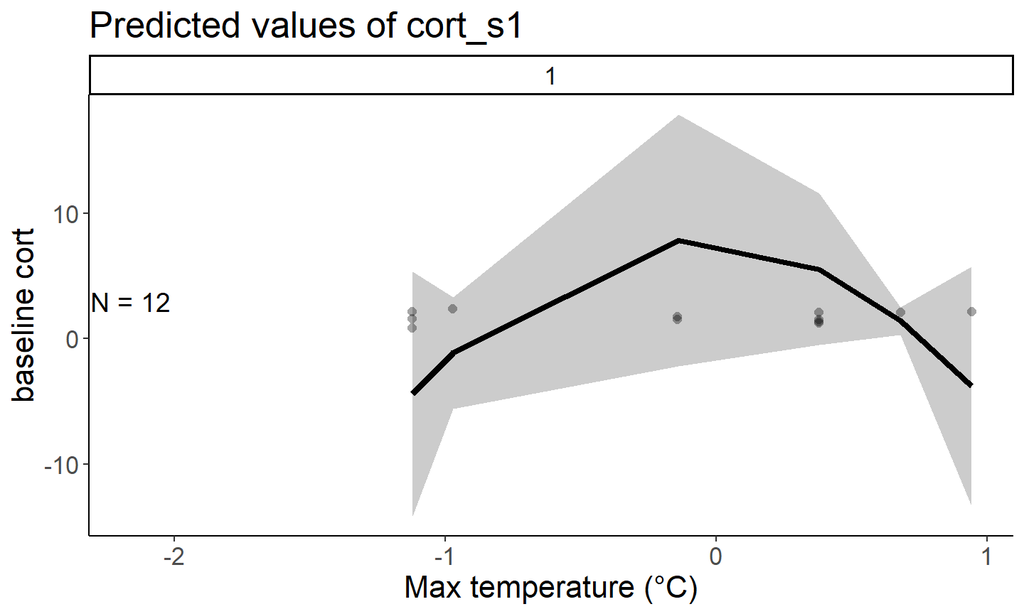

## Cort across temp and habitat: TRES, orchard

For original model with min temp:

| model | npar | AIC | BIC | logLik | deviance | Chisq | Df | Pr(>Chisq) |
| --- | --- | --- | --- | --- | --- | --- | --- | --- |
| no sq | 9 | 20.43504 | 23.15831 | -1.217521 | 2.435041 | NA | NA | NA |
| no min sq | 9 | 20.43504 | 23.15831 | -1.217521 | 2.435041 | 0 | 0 | NA |
| sq max and min | 9 | 20.43504 | 23.15831 | -1.217521 | 2.435041 | 0 | 0 | NA |

| model | npar | AIC | BIC | logLik | deviance | Chisq | Df | Pr(>Chisq) |
| --- | --- | --- | --- | --- | --- | --- | --- | --- |
| no sq | 9 | 20.43504 | 23.15831 | -1.217521 | 2.435041 | NA | NA | NA |
| no max sq | 9 | 20.43504 | 23.15831 | -1.217521 | 2.435041 | 0 | 0 | NA |
| sq max and min | 9 | 20.43504 | 23.15831 | -1.217521 | 2.435041 | 0 | 0 | NA |

```
## Linear mixed model fit by REML. t-tests use Satterthwaite's method [
## lmerModLmerTest]
## Formula:
## cort_s1_scaled ~ poly(meanmaxtempI_scaled, 2, raw = TRUE) + poly(meanmintempI_scaled,
##     2) + poly(meanmaxtempI_scaled, 2, raw = TRUE) * meanh_scaled +
##     brood_size + age_scaled + juliandate_scaled + (1 | year) +
##     (1 | site/attempt_id)
##    Data:
## (dplyr::filter(g, habitat == "Orchard", Species == "TRES", !is.na(meanmaxtempI),
##     !is.na(cort_s1)) %>% mutate(across(c(cort_s1, meanmaxtempI,
##     meanmintempI, meanh, cort_s1_mother, age, juliandate), ~scale(.x)[,
##     1], .names = "{.col}_scaled"), meanmaxtempI_scaled_sq = meanmaxtempI_scaled *
##     meanmaxtempI_scaled))
##
## REML criterion at convergence: 5.6
##
## Scaled residuals:
##      Min       1Q   Median       3Q      Max
## -1.05023 -0.38012 -0.00233  0.14616  1.49209
##
## Random effects:
##  Groups          Name        Variance Std.Dev.
##  attempt_id:site (Intercept) 6.37499  2.5249
##  site            (Intercept) 0.02548  0.1596
##  year            (Intercept) 0.88586  0.9412
##  Residual                    0.14939  0.3865
## Number of obs: 10, groups:  attempt_id:site, 4; site, 2; year, 2
##
## Fixed effects:
##                                           Estimate Std. Error       df t value
## (Intercept)                               -0.75237    3.03772  5.00000  -0.248
## poly(meanmaxtempI_scaled, 2, raw = TRUE)1 -0.07806    3.84408  5.00000  -0.020
## poly(meanmaxtempI_scaled, 2, raw = TRUE)2 -0.26483    0.84140  5.00000  -0.315
## poly(meanmintempI_scaled, 2)1              8.15566   14.81018  5.00000   0.551
## poly(meanmintempI_scaled, 2)2             -4.66139   14.83057  5.00000  -0.314
##                                           Pr(>|t|)
## (Intercept)                                  0.814
## poly(meanmaxtempI_scaled, 2, raw = TRUE)1    0.985
## poly(meanmaxtempI_scaled, 2, raw = TRUE)2    0.766
## poly(meanmintempI_scaled, 2)1                0.606
## poly(meanmintempI_scaled, 2)2                0.766
##
## Correlation of Fixed Effects:
##                 (Intr) p(I_,2,r=TRUE)1 p(I_,2,r=TRUE)2 p(I_,2)1
## p(I_,2,r=TRUE)1  0.665
## p(I_,2,r=TRUE)2 -0.151  0.419
## ply(mI_,2)1     -0.798 -0.641           0.031
## ply(mI_,2)2      0.846  0.894           0.017          -0.839
## fit warnings:
## fixed-effect model matrix is rank deficient so dropping 6 columns / coefficients
## optimizer (nloptwrap) convergence code: 0 (OK)
## unable to evaluate scaled gradient
## Model failed to converge: degenerate  Hessian with 1 negative eigenvalues
```

Same problem as for forest

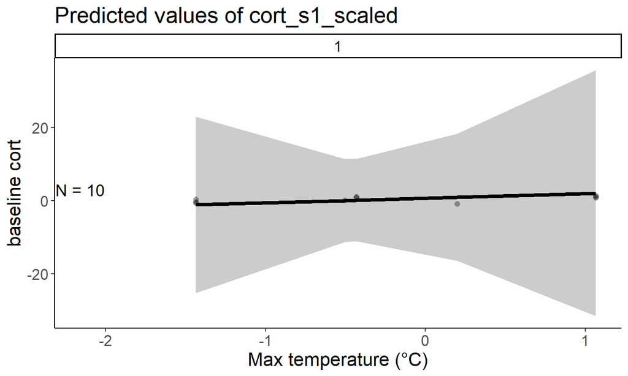